# Figures 3, 4, 5, 6, and S1 from MacCoss QC manuscript

Kristine A. Tsantilas, PhD

2024-02-14

# Overview

This R Markdown file generates Figures 3, 4, 5, and 6 and Supplementary Figure 1 from the MacCoss laboratory’s manuscript describing approaches to quality control spanning sample preparation, system suitability, and quantitative results.

## Experiments

Summary of figures included in the preprint:.

- **Figure 1:** Visual summary of the QCs discussed in the manuscript. No experiments, and not generated by this script.
- **Figure 2:** System suitability run by multiple technicians before, during, and after multiple experiments. Not generated by this script.
- **Figure 3:** DDA and PRM system suitability runs on the same system over several years.
- **Figure 4:** DIA sample runs where one of four sample digestion conditions resulted in loss of sample signal.
- **Figure 5:** DIA sample runs where one injection had altered retention times and significantly reduced signal due to an LC failure.
- **Figure 6:** DIA samples and system suitability runs on the same system used to identify a severe instrument defect.
- **Figure 7:** External quality control DIA runs used to assess quantitative results. Not generated by this script
- **Supplementary Figure 1:** Expanded figure panels containing same data as Figure 4, but adding PRTC peptides and an additional enolase peptide.

# Script

## Input

The necessary input files by figure are listed below:

#### Figure 4

- **figure4_PRM_system_suitability.sky.zip**
  - **Figure4_PRM_PeakArea_RetTime_Chromatogram_Export.csv:** Peak areas, retention times, and chromatography data from PRM system suitability runs
  - **Figure4_PRM_metadata.csv:** Metadata of PRM system suitability runs.
- **figure4_DIA_samples.sky.zip**
  - **Figure4_DIA_PeakArea_RetTime_Chromatogram_Export.csv:** Peak areas, retention times, and chromatography data from DIA sample runs.
  - **Figure4_DIA_metadata.csv:** Metadata of DIA samples runs.

#### Figure 5

- **Figure5_PRM_PeakArea_RetTime_Chromatogram_Export.csv:** Peak areas, retention times, and chromatography data from PRM system suitability runs.
- **Figure5_DIA_PeakArea_RetTime_Chromatogram_Export.csv:** Peak areas, retention times, and chromatography data from DIA sample runs.
- **Figure5_PRM_metadata.csv:** Metadata of PRM system suitability runs.
- **Figure5_DIA_metadata.csv:** Metadata of DIA samples runs.

#### Figure 6

- **Figure6_DIA_LongForm_Peptide_TAF.csv:** Skyline document grid exported .csv of total area fragments of DIA sample runs
- **Figure6_PRM_LongForm_Peptide_TAF.csv:** Skyline document grid exported .csv of total area fragments of PRM system suitability runs.
- **Figure6_DIA_metadata.csv:** Metadata of DIA samples runs.
- **Figure6_PRM_metadata.csv:** Metadata of PRM system suitability runs.
- **Figure6_timeline_format.csv:** Organizer .csv to set-up and label Figure 6A.
- **Figure6_Run_Organizer.csv:** Organizer .csv to set-up and label Figure 6B.

## Output

The resulting output files by figure are listed below:

- **Figure 3:** Figure3.svg
- **Figure 4:** Figure4.svg
- **Figure 5:** Figure5.svg
- **Figure 6:** Figure6.svg

## Software Information

- Skyline Daily (64-bit): Documents exported with compatibility for stable release 22.2.
- R version: 4.1.2
- R Studio version: 2023.03.0+386 “Cherry Blossom” Release (3c53477afb13ab959aeb5b34df1f10c237b256c3, 2023-03-09) for Windows Mozilla/5.0 (Windows NT 10.0; Win64; x64) AppleWebKit/537.36 (KHTML, like Gecko) RStudio/2023.03.0+386 Chrome/108.0.5359.179 Electron/22.0.3 Safari/537.36
- Packages required:
  - knitr (version 1.43)
  - kableExtra (version 1.3.4)
  - dplyr (version 1.1.2)
  - stringr (version 1.5.0)
  - tidyr (version 1.3.0)
  - matrixStats (version 0.63.0)
  - tibble (version 3.2.1)
  - ggplot2 (version 3.4.2)
  - forcats (version 1.0.0)
  - ggnewscale (version 0.4.9)
  - RColorBrewer (version 1.1-3)
  - magick (version 2.7.4)
  - patchwork (version 1.1.2)

```r
knitr::opts_chunk$set(echo = TRUE, collapse = TRUE, warning=FALSE, message=FALSE)
```

```r
# Check location of working directory
getwd()

# Set-up current date to include in filename output
(today <- Sys.Date())
basename <- today %>%
            format(., "%Y%b%d") %>% # with month as a word
            paste0(.,"_")

# Set-up base filenames by dataset to classify filename output
filenamebase <- "MacCossQC_"
```

## Internal Quality Controls

Summary of peptides used as part of the internal quality controls (introduced at protein or peptide level) to monitor data and sample quality in this study.

- SS = System Suitability (PRM)
- IQC = Internal Quality Controls (DIA) in sample runs

$~$

```r
# Vector of all PRTC peptides considered in study
PRTC <- c("SSAAPPPPPR",
              "GISNEGQNASIK",
              "HVLTSIGEK",
              "DIPVPKPK",
              "IGDYAGIK",
              "TASEFDSAIAQDK",
              "SAAGAFGPELSR",
              "ELGQSGVDTYLQTK",
              "GLILVGGYGTR",
              "GILFVGSGVSGGEEGAR",
              "SFANQPLEVVYSK",
              "LTILEELR",
              "NGFILDGFPR",
              "ELASGLSFPVGFK",
              "LSSEAPALFQFDLK")

YENO1 <- c("NVNDVIAPAFVK", "AVDDFLISLDGTANK", "LGANAILGVSLAASR", "TAGIQIVADDLTVTNPK", "AADALLLK", "VNQIGTLSESIK")

BSA <- c("LVNELTEFAK", "ATEEQLK")


PRTC_tab <- as.data.frame(PRTC)
PRTC_tab <- PRTC_tab %>%
            rename("Peptide Sequence" = "PRTC") %>%
            mutate("Peptide Source" = "PRTC",
                   "Run Type" = "SS, IQC")

BSA_tab <- as.data.frame(BSA)
BSA_tab <- BSA_tab %>%
            rename("Peptide Sequence" = "BSA") %>%
            mutate("Peptide Source" = "BSA",
                   "Run Type" = "SS")

YENO1_tab <- as.data.frame(YENO1)
YENO1_tab <- YENO1_tab %>%
            rename("Peptide Sequence" = "YENO1") %>%
            mutate("Peptide Source" = "YENO1",
                   "Run Type" = "IQC")

all_qc <- rbind(PRTC_tab, BSA_tab, YENO1_tab)
```

```r
# Table of all internal quality control peptides considered in study.
knitr::kable(all_qc, caption = "Internal QC Peptides", booktabs = TRUE, linesep = "", align = 'l') %>%
  kable_styling(latex_options = "scale_down", font_size = 12) %>%
  scroll_box(height = "350px")
```

Internal QC Peptides

| Peptide Sequence | Peptide Source | Run Type |
| --- | --- | --- |
| SSAAPPPPPR | PRTC | SS, IQC |
| GISNEGQNASIK | PRTC | SS, IQC |
| HVLTSIGEK | PRTC | SS, IQC |
| DIPVPKPK | PRTC | SS, IQC |
| IGDYAGIK | PRTC | SS, IQC |
| TASEFDSAIAQDK | PRTC | SS, IQC |
| SAAGAFGPELSR | PRTC | SS, IQC |
| ELGQSGVDTYLQTK | PRTC | SS, IQC |
| GLILVGGYGTR | PRTC | SS, IQC |
| GILFVGSGVSGGEEGAR | PRTC | SS, IQC |
| SFANQPLEVVYSK | PRTC | SS, IQC |
| LTILEELR | PRTC | SS, IQC |
| NGFILDGFPR | PRTC | SS, IQC |
| ELASGLSFPVGFK | PRTC | SS, IQC |
| LSSEAPALFQFDLK | PRTC | SS, IQC |
| LVNELTEFAK | BSA | SS |
| ATEEQLK | BSA | SS |
| NVNDVIAPAFVK | YENO1 | IQC |
| AVDDFLISLDGTANK | YENO1 | IQC |
| LGANAILGVSLAASR | YENO1 | IQC |
| TAGIQIVADDLTVTNPK | YENO1 | IQC |
| AADALLLK | YENO1 | IQC |
| VNQIGTLSESIK | YENO1 | IQC |

## File Import

Importing data files.

$~$

```r
## Read in data exported from Skyline, metadata, and additional tables (.csv files) to organize figure panels


## Figure 3
    fig3_dda <- read.table("input\\Figure3_DDA_Limelight_PSMs.txt",
                                header = TRUE,
                                sep = "\t")

    fig3_prm_rt_chrom <- read.csv("input\\Figure3_PRM_PeakArea_RetTime_Chromatogram_Export.csv",
                                  header = TRUE,
                                  na.strings="#N/A",
                                  sep = ",")

    fig3_prm_ms1_idotp <- read.csv("input\\Figure3_PRM_MS1area_idotp.csv",
                                  header = TRUE,
                                  na.strings="#N/A",
                                  sep = ",")

    fig3_prm_metadata <- read.csv("input\\Figure3_PRM_metadata.csv",
                                  header = TRUE,
                                  na.strings="#N/A",
                                  sep = ",")

## Figure 4
    # Long-format file containing peak areas, retention times, and chromatogram intensities/times to make reproducible figure replicating skyline panels
    fig4_pa_rt_chrom <- read.csv("input\\Figure4_DIA_PeakArea_RetTime_Chromatogram_Export.csv",
                                  header = TRUE,
                                  na.strings="#N/A",
                                  sep = ",")

    # Metadata for Figure 4
      fig4_meta <- read.csv("input\\Figure4_DIA_metadata.csv",
                                  header = TRUE,
                                  na.strings="#N/A",
                                  sep = ",")


## Figure 5
    # Long-format file containing peak areas, retention times, and chromatogram intensities/times to make reproducible figure replicating skyline panels
      fig5_pa_rt_chrom <- read.csv("input\\Figure5_DIA_PeakArea_RetTime_Chromatogram_Export.csv",
                                  header = TRUE,
                                  na.strings="#N/A",
                                  sep = ",")

    # Metadata for Figure 5
      fig5_meta <- read.csv("input\\Figure5_DIA_metadata.csv",
                                  header = TRUE,
                                  na.strings="#N/A",
                                  sep = ",")


## Figure 6
    # Table to organize subset of runs plotted in Figure 6. Note that all runs are available on Panorama - only subset plotted here to improve visualization.
    organizer <- read.csv("input\\Figure6_Run_Organizer.csv",
                                  header = TRUE,
                                  na.strings="#N/A",
                                  sep = ",")

    # Table to format maintenance timeline that is used in panel 6A
      fig6_timeline <- read.csv("input\\Figure6_timeline_format.csv",
                                  header = TRUE,
                                  na.strings="#N/A",
                                  sep = ",")

    # Import system suitability controls from PRM runs.
      SS_TAF <- read.csv("input\\Figure6_PRM_LongForm_Peptide_TAF.csv",
                                  header = TRUE,
                                  na.strings="#N/A",
                                  sep = ",")
            SS_TAF <- SS_TAF %>%
                       mutate(Group = "SS")


    # Import internal quality controls from DIA runs.
      IQC_TAF <- read.csv("input\\Figure6_DIA_LongForm_Peptide_TAF.csv",
                                  header = TRUE,
                                  na.strings="#N/A",
                                  sep = ",")
            IQC_TAF <- IQC_TAF %>%
                       mutate(Group = "IQC")

    # Import system suitability controls from PRM runs.
      SS_meta <- read.csv("input\\Figure6_PRM_metadata.csv",
                                  header = TRUE,
                                  na.strings="#N/A",
                                  sep = ",")
            SS_meta <- SS_meta %>%
                       rename("Batch" = "Group")

    # Import internal quality controls from DIA runs.
      IQC_meta <- read.csv("input\\Figure6_DIA_metadata.csv",
                                  header = TRUE,
                                  na.strings="#N/A",
                                  sep = ",")
            IQC_meta <- IQC_meta %>%
                       rename("Batch" = "Group")
```

# Figure 3

## Tidying

DDA runs: Simplifying column names and batch names. Calculating averages and standard deviations of peptide identifications and PSMs.

$~$

```r
fig3_batches <- c("2014_12","2015_4", "2015_5", "2016_2", "2016_3")

    fig3_dda_L <- fig3_dda %>%
                      rename(.,
                             "Proteins" = "Protein.s.",
                             "2014_12-1" = "PSMs..4_12_1.p.",
                             "2014_12-2" = "PSMs..4_12_2.p.",
                             "2014_12-3" = "PSMs..4_12_3.p.",
                             "2015_4-1" = "PSMs..5_4_1.pe.",
                             "2015_4-2" = "PSMs..5_4_2.pe.",
                             "2015_4-3" = "PSMs..5_4_3.pe.",
                             "2016_2-1" = "PSMs..6_2_1.pe.",
                             "2016_2-2" = "PSMs..6_2_2.pe.",
                             "2016_2-3" = "PSMs..6_2_3.pe.",
                             "2016_3-1" = "PSMs..6_3_1.pe.",
                             "2016_3-2" = "PSMs..6_3_2.pe.",
                             "2016_3-3" = "PSMs..6_3_3.pe.") %>%
                      gather(., Replicate, PSMs_ByRep, "2014_12-1":"2016_3-3", factor_key=FALSE) %>%
                      mutate(.,
                             Batch = str_extract(Replicate, "(?:(?!-).)*"))


fig3_dda_L$Batch <- factor(fig3_dda_L$Batch, levels=c("2014_12","2015_4","2016_2", "2016_3"))
levels(fig3_dda_L$Batch) <- list("2014" = "2014_12",
                                 "2015" = "2015_4",
                                 "2016-1" = "2016_2",
                                 "2016-2" = "2016_3")


fig3_dda_psms <- fig3_dda_L %>%
                        group_by(Replicate) %>%
                        reframe(Replicate = unique(Replicate),
                                Batch = unique(Batch),
                                SumPSM = sum(PSMs_ByRep))

fig3_dda_pep <- fig3_dda_L %>%
                        filter(PSMs_ByRep != "0") %>%
                        group_by(Replicate) %>%
                        reframe(Replicate = unique(Replicate),
                                Batch = unique(Batch),
                                Num_Peptides = n_distinct(Peptide.Sequence))

fig3_dda_psms_summary <- fig3_dda_psms %>%
                        group_by(Batch) %>%
                        reframe(Batch = unique(Batch),
                                Avg = mean(SumPSM),
                                SD = sd(SumPSM))

fig3_dda_pep_summary  <- fig3_dda_pep %>%
                        group_by(Batch) %>%
                        reframe(Batch = unique(Batch),
                                Avg = mean(Num_Peptides),
                                SD = sd(Num_Peptides))
```

PRM runs: Simplifying column names and batch names. Rounding idotp values.

$~$

```r
fig3_prm_rt_chrom <- fig3_prm_rt_chrom %>%
                        rename(.,
                              "Replicate" = "Replicate.Name",
                              "Protein.Name" = "Protein")

fig3_prm_part <- full_join(fig3_prm_rt_chrom, fig3_prm_metadata, by = c("Replicate","Group"))

fig3_prm <- full_join(fig3_prm_part, fig3_prm_ms1_idotp, by = c("File.Name","Peptide.Modified.Sequence","Protein.Name"))

fig3_prm <- fig3_prm %>%
             rename(.,
                    "Batch" = "Group")

fig3_prm$Batch <- factor(fig3_prm$Batch, levels=c("2014","2015", "2016-1", "2016-2"))


# Rounding the idotp value to make visualizing them in the chromatograms easier.
fig3_prm <- fig3_prm %>%
            mutate(idotp_rounded = format(round(Isotope.Dot.Product, digits = 2), nsmall = 2))
```

## Functions

Defined 2 functions with the following input parameters to put together Figure 3:

- fig3_ms1_chromatogram: Plotting the MS1 chromatogram of PRM runs.
  - dataframe: Peak areas, retention times, and chromatography data from DIA sample runs
  - replicate_name: Sample replicate to extract chromatograms
  - peptide: Peptide sequence to plot
  - time_col: Measured times
  - intensity_col: Intensity at the measured times
  - y_axis_max: Setting a y-axis maximum based on the peak apex wth a buffer
  - label_buffer: Setting a buffer between the peak apex and the idotp value label
  - x_min_buffer_5: Setting a buffer between early peak edge and y-axis
  - x_max_buffer_5: Setting a buffer between late peak edge and graph edge
  - x_axis_label: Text of the x-axis label. May be left blank by using ““.
  - y_axis_label: Text of the y-axis label. May be left blank by using ““.
  - fig3_subtitle: Used to add a title to the panel. May be left blank by using ““.
  - fig3_top_margin: Setting margin at the top of the plot area
- fig3_taf: Plotting the average total area fragment of specific peptides PRM runs.
  - dataframe: Peak areas, retention times, and chromatography data from DIA sample runs runs shown in Figure 5.
  - peptide: Peptide sequence to plot
  - y_axis_maximum: Setting a y-maximum based on the most abundant summed fragment ion peak and adding a buffer.

$~$

```r
fig3_ms1_chromatogram <- function(dataframe, replicate_name, peptide, time_col, intensity_col, y_axis_max, label_buffer, x_min_buffer_5, x_max_buffer_5, x_axis_label, y_axis_label, fig3_subtitle, fig3_top_margin){

  subdata <- dataframe %>%
             filter(Replicate == replicate_name) %>%
             filter(Peptide.Modified.Sequence == peptide) %>%
             filter(Fragment.Ion == "precursor" | Fragment.Ion == "precursor [M+1]" | Fragment.Ion == "precursor [M+2]") %>%
             rename("Time" = time_col,
                    "Intensity" = intensity_col)

    subdata_chromatogram <- subdata %>%
                     separate_longer_delim(., cols = c("Time", "Intensity"), delim = ",") %>%
                     group_by(Fragment.Ion)

  subdata_chromatogram <- transform(subdata_chromatogram, Time = as.numeric(Time))
  subdata_chromatogram <- transform(subdata_chromatogram, Intensity = as.numeric(Intensity))

chrom_x_min <- (min(subdata_chromatogram$Best.Retention.Time) - x_min_buffer_5)
chrom_x_max <- (max(subdata_chromatogram$Best.Retention.Time) + x_max_buffer_5)

chrom_label_y <- ((max(subdata_chromatogram$Intensity))+(max(subdata_chromatogram$Intensity)*label_buffer))
chrom_label_x <- (median(subdata_chromatogram$Best.Retention.Time))
chrom_idotp <- (unique(subdata_chromatogram$idotp_rounded))

chromatogram_plot  <-  (ggplot(subdata_chromatogram,
              aes(group = Fragment.Ion,
                  color = Fragment.Ion,
                  x = Time,
                  y =  Intensity)) +

  geom_line(linewidth = 1.5) +
               theme_minimal()+
               theme(plot.margin = margin(fig3_top_margin, 0, 0, 0.05, "in"),  # t, r, b, l
                     panel.grid.major.x = element_blank(),
                     panel.grid.major.y = element_line(color="azure3"),
                     panel.grid.minor.x = element_blank(),
                     panel.grid.minor.y = element_blank(),
                     axis.text.x = element_text(size=18, color = "black", angle = 90, margin = margin(t=0, r=0, b=10, l=0)),
                     axis.text.y = element_text(size=18, color = "black", margin = margin(t=0, r=5, b=0, l=10)),
                     axis.title.x = element_text(size = 22, color = "black", hjust = 0.5, margin = margin(t = 0, r = 0, b = 0, l = 0)),
                     axis.title.y = element_text(size = 22, color = "black", margin = margin(t = 0, r = 0, b = 0, l = 0)),
                     legend.position = "none",
                     plot.title=element_text(size=22, color = "black", hjust = 0.5)
                     ) +
                ggtitle(fig3_subtitle) +
                scale_color_manual(values = ms1_Palette) +
                scale_x_continuous(name=x_axis_label, limits=c(chrom_x_min, chrom_x_max)) +
                scale_y_continuous(name=y_axis_label, limits=c(0, y_axis_max)) +
                geom_hline(yintercept=0, linetype="solid", color = "black", linewidth=1) +
                geom_vline(xintercept=chrom_x_min, linetype="solid", color = "black", linewidth=1)) +
                annotate("text", x = chrom_label_x, y = chrom_label_y, label = chrom_idotp, size = 9)


chromatogram_plot

}


fig3_taf <- function(dataframe, peptide, y_axis_maximum){


fig3_subdata <- dataframe %>%
                 filter(Peptide.Modified.Sequence == peptide) %>%
                 group_by(Batch) %>%
                 reframe(Batch = unique(Batch),
                         Avg = mean(Total.Area.Fragment),
                         SD = sd(Total.Area.Fragment))

  # Plot TAF
    Plot_fig3_PRM_prtc_taf <- (ggplot(data=fig3_subdata, aes(x=Batch, y=Avg, fill=Batch)) +
                               geom_bar(stat = "identity", fun = "mean") +
                                geom_errorbar(aes(ymin=Avg-SD, ymax=Avg+SD), width=.2, position=position_dodge(.9)) +
                                theme_minimal()+
                                theme(plot.margin = margin(0.3, 0, 0, 0, "in"),  # t, r, b, l
                                      panel.grid.major.x = element_blank(),
                                      panel.grid.major.y = element_line(color="azure3"),
                                      panel.grid.minor.x = element_blank(),
                                      panel.grid.minor.y = element_blank(),
                                      axis.text.x = element_text(size=16, color = "black",angle = 90, vjust = 0.5, hjust=1),
                                      axis.text.y = element_text(size=16, color = "black"),
                                      axis.title.x = element_blank(),
                                      axis.title.y = element_text(size = 18, color = "black", margin = margin(t = 0, r = 0, b = 0, l = 0)),
                                      legend.position = "none",
                                      plot.title=element_text(size=22, color = "black", hjust = 0.5)) +
                                 ggtitle(peptide) +
                                 geom_hline(yintercept=0, linetype="solid", color = "black", linewidth=0.5) +
                                 ylim(0,((y_axis_maximum)+(y_axis_maximum*.05))) +
                                 scale_x_discrete(name="Run Date") +
                                 scale_y_continuous(name="Total Area Fragment") +
                                 scale_fill_manual(values = c("2014" = cbPalette[1], "2015" = cbPalette[8], "2016-1" = cbPalette[6], "2016-2" = cbPalette[2])))

Plot_fig3_PRM_prtc_taf
}
```

## Figure 3

**Shared Color Palettes**

Setting-up colorblind-friendly color palettes to use in Figure 3.

$~$

```r
# Figure 3 MS1 chromatogram color palette
  # ms1_Palette <- c("#000999", "#009E73","#D55E00")
  ms1_Palette <- c("#D55E00", "#009E73","#000999")

# Figure 3 color palette for DDA PSMs and peptide IDs, and PRM TAF.
cbPalette <- c("#999999", "#E69F00", "#56B4E9", "#009E73", "#F0E442", "#0072B2", "#D55E00", "#CC79A7", "#000000")
```

**Figure 3A**

Generating a ggplot object of a timeline of significant maintenance.

$~$

```r
fig3_timeline <- read.csv("input/Figure3_timeline_format.csv")

## Plotting rough maintenance timeline to correspond with the data in 3B-G
figure3a <- (ggplot(data = fig3_timeline, aes(x=Position_x, y=Position_y)) +
          theme_void()+
          theme(plot.margin = margin(0.2, 0, 0.2, 0, "in"),  # t, r, b, l
                axis.title.x=element_blank(),
                axis.title.y=element_blank(),
                axis.text.x=element_blank(),
                axis.text.y=element_blank(),
                axis.ticks.x=element_blank(),
                axis.ticks.y=element_blank(),
                axis.line.x=element_blank(),
                axis.line.y=element_blank()) +
          coord_fixed(xlim=c(0,100),
                  ylim = c(0, 75),
                  clip = 'off') +
          geom_segment(data=fig3_timeline, aes(y=20,yend=20,x=-250,xend=350), color='black', size=3) +

          annotate("text", x = 50, y = 75, label="Significant Maintenance Timeline", colour = "black", size=9) +
          geom_segment(data=fig3_timeline, aes(y=20,yend=(Position_y+(1.5*Orientation)),x=Position_x,xend=Position_x), color='black', size=1) +
          geom_point(data = fig3_timeline, aes(x=Position_x, y=20), size=8, shape=21, fill = "azure4", colour = "black") +

          geom_label(data=fig3_timeline, aes(x=Position_x, y=(Position_y+(1.5*Orientation)),label=Note),size=7,vjust=0.5,hjust= 0.05,color='black') #+

)

figure3a
```

**Figure 3B, 3C, 3F, and 3G**

$~$

```r
# Shared variables
fig3_panel_w <- 5
fig3_panel_h <- 5

fig3_shared_x <- "Time (Minutes)"
fig3_shared_y <- "Intensity"

rep_2014 <- "2014_12_5"
rep_2015 <- "2015_4_2"
rep_2016 <- "2016_2_2"
rep_2016_2 <- "2016_3_5"


fig3_bsa <- "LVNELTEFAK"
fig3_bsa_yax <- (2.3e9)

fig3_prtc <- "GLILVGGYGTR"  #Coalescence in 2016
fig3_prtc_yax <- (750e6)

fig3_prtc2 <- "GISNEGQNASIK"  # Coalescence everywhere
fig3_prtc2_yax <- (725e6)


fig3_prtc_2014_chrom <- fig3_ms1_chromatogram(dataframe = fig3_prm,
                                              replicate_name = rep_2014,
                                              peptide = fig3_prtc,
                                              time_col ="Raw.Times",
                                              intensity_col = "Raw.Intensities",
                                              y_axis_max = fig3_prtc_yax,
                                              label_buffer = 0.3,
                                              x_min_buffer_5 = 0.15,
                                              x_max_buffer_5 = 0.15,
                                              x_axis_label = "",
                                              y_axis_label = fig3_shared_y,
                                              fig3_subtitle = fig3_prtc,
                                              fig3_top_margin = 0.075)

fig3_prtc_2015_chrom <- fig3_ms1_chromatogram(dataframe = fig3_prm,
                                              replicate_name = rep_2015,
                                              peptide = fig3_prtc,
                                              time_col ="Raw.Times",
                                              intensity_col = "Raw.Intensities",
                                              y_axis_max = fig3_prtc_yax,
                                              label_buffer = 0.4,
                                              x_min_buffer_5 = 0.2,
                                              x_max_buffer_5 = 0.4,
                                              x_axis_label = "",
                                              y_axis_label = "",
                                              fig3_subtitle = "",
                                              fig3_top_margin = 0.075)

fig3_prtc_2016_chrom <- fig3_ms1_chromatogram(dataframe = fig3_prm,
                                              replicate_name = rep_2016,
                                              peptide = fig3_prtc,
                                              time_col ="Raw.Times",
                                              intensity_col = "Raw.Intensities",
                                              y_axis_max = fig3_prtc_yax,
                                              label_buffer = 0.085,
                                              x_min_buffer_5 = 0.2,
                                              x_max_buffer_5 = 0.2,
                                              x_axis_label = "",
                                              y_axis_label = "",
                                              fig3_subtitle = "",
                                              fig3_top_margin = 0.075)

fig3_prtc_2016_2_chrom <- fig3_ms1_chromatogram(dataframe = fig3_prm,
                                                replicate_name = rep_2016_2,
                                                peptide = fig3_prtc,
                                                time_col ="Raw.Times",
                                                intensity_col = "Raw.Intensities",
                                                y_axis_max = fig3_prtc_yax,
                                                label_buffer = 0.15,
                                                x_min_buffer_5 = 0.2,
                                                x_max_buffer_5 = 0.2,
                                                x_axis_label = "",
                                                y_axis_label = "",
                                                fig3_subtitle = "",
                                                fig3_top_margin = 0.075)

fig3_prtc_taf <- fig3_taf(dataframe = fig3_prm,
                          peptide = fig3_prtc,
                          y_axis_maximum = (450e6))




fig3_bsa_2014_chrom <- fig3_ms1_chromatogram(dataframe = fig3_prm,
                                             replicate_name = rep_2014,
                                             peptide = fig3_bsa,
                                             time_col ="Raw.Times",
                                             intensity_col = "Raw.Intensities",
                                             y_axis_max = fig3_bsa_yax,
                                             label_buffer = 0.4,
                                             x_min_buffer_5 = 0.15,
                                             x_max_buffer_5 = 0.15,
                                             x_axis_label = fig3_shared_x,
                                             y_axis_label = fig3_shared_y,
                                             fig3_subtitle = fig3_bsa,
                                             fig3_top_margin = 0.05)

fig3_bsa_2015_chrom <- fig3_ms1_chromatogram(dataframe = fig3_prm,
                                             replicate_name = rep_2015,
                                             peptide = fig3_bsa,
                                             time_col ="Raw.Times",
                                             intensity_col = "Raw.Intensities",
                                             y_axis_max = fig3_bsa_yax,
                                             label_buffer = 0.4,
                                             x_min_buffer_5 = 0.2,
                                             x_max_buffer_5 = 0.4,
                                             x_axis_label = "",
                                             y_axis_label = "",
                                             fig3_subtitle = "",
                                             fig3_top_margin = 0.05)

fig3_bsa_2016_chrom <- fig3_ms1_chromatogram(dataframe = fig3_prm,
                                             replicate_name = rep_2016,
                                             peptide = fig3_bsa,
                                             time_col ="Raw.Times",
                                             intensity_col = "Raw.Intensities",
                                             y_axis_max = fig3_bsa_yax,
                                             label_buffer = 0.2,
                                             x_min_buffer_5 = 0.2,
                                             x_max_buffer_5 = 0.2,
                                             x_axis_label = "",
                                             y_axis_label = "",
                                             fig3_subtitle = "",
                                             fig3_top_margin = 0.05)

fig3_bsa_2016_2_chrom <- fig3_ms1_chromatogram(dataframe = fig3_prm,
                                               replicate_name = rep_2016_2,
                                               fig3_bsa,
                                               time_col ="Raw.Times",
                                               intensity_col = "Raw.Intensities",
                                               y_axis_max = fig3_bsa_yax,
                                               label_buffer = 0.15,
                                               x_min_buffer_5 = 0.2,
                                               x_max_buffer_5 = 0.2,
                                               x_axis_label = "",
                                               y_axis_label = "",
                                               fig3_subtitle = "",
                                               fig3_top_margin = 0.05)

fig3_bsa_taf <- fig3_taf(dataframe = fig3_prm,
                         peptide = fig3_bsa,
                         y_axis_maximum = (450e6))
```

$~$

```r
# Plot peptides
    fig3_DDA_Peptide <- (ggplot(data=fig3_dda_pep_summary, aes(x=Batch, y=Avg, fill=Batch)) +
                           geom_bar(stat = "identity", fun = "mean") +
                          geom_errorbar(aes(ymin=Avg-SD, ymax=Avg+SD), width=.2, position=position_dodge(.9)) +
                          theme_minimal()+
                          theme(plot.margin = margin(0.3, 0, 0, 0, "in"),  # t, r, b, l
                                panel.grid.major.x = element_blank(),
                                panel.grid.major.y = element_line(color="azure3"),
                                panel.grid.minor.x = element_blank(),
                                panel.grid.minor.y = element_blank(),
                                axis.text.x = element_text(size=16, color = "black",angle = 90, vjust = 0.5, hjust=1),
                                axis.text.y = element_text(size=16, color = "black"),
                                axis.title.x = element_blank(),
                                axis.title.y = element_text(size = 18, color = "black", margin = margin(t = 0, r = 0, b = 0, l = 0)),
                                legend.position = "none"
                                ) +
                          geom_hline(yintercept=0, linetype="solid", color = "black", linewidth=0.5) +
                          ylim(0,(max(fig3_dda_pep$Num_Peptides)+(max(fig3_dda_pep$Num_Peptides)*.05))) +
                          scale_x_discrete(name="Run Date") +
                          scale_y_continuous(name="Average Peptides", breaks=c(2500,5000,7500)) +
                          scale_fill_manual(values = c("2014" = cbPalette[1], "2015" = cbPalette[8], "2016-1" = cbPalette[6], "2016-2" = cbPalette[2])))

    fig3_DDA_PSM <- (ggplot(data=fig3_dda_psms_summary, aes(x=Batch, y=Avg, fill=Batch)) +
                       geom_bar(stat = "identity", fun = "mean") +
                          geom_errorbar(aes(ymin=Avg-SD, ymax=Avg+SD), width=.2, position=position_dodge(.9)) +
                          theme_minimal()+
                          theme(plot.margin = margin(0.3, 0, 0, 0, "in"),  # t, r, b, l
                                panel.grid.major.x = element_blank(),
                                panel.grid.major.y = element_line(color="azure3"),
                                panel.grid.minor.x = element_blank(),
                                panel.grid.minor.y = element_blank(),
                                axis.text.x = element_text(size=16, color = "black",angle = 90, vjust = 0.5, hjust=1),
                                axis.text.y = element_text(size=16, color = "black"),
                                axis.title.x = element_blank(),
                                axis.title.y = element_text(size = 18, color = "black", margin = margin(t = 0, r = 0, b = 0, l = 0)),
                                legend.position = "none"
                                ) +
                          geom_hline(yintercept=0, linetype="solid", color = "black", linewidth=0.5) +
                          ylim(0,(max(fig3_dda_pep$Num_Peptides)+(max(fig3_dda_pep$Num_Peptides)*.05))) +
                          scale_x_discrete(name="Run Date") +
                          scale_y_continuous(name="Average PSMs", breaks=c(3000,6000,9000,12000)) +
                          scale_fill_manual(values = c("2014" = cbPalette[1], "2015" = cbPalette[8], "2016-1" = cbPalette[6], "2016-2" = cbPalette[2])))
```

**Figure 3**

$~$

```r
# Setting up layout for final figure to assemble all panels of Supplementary Figure S1. Order important for proper annotations.
  fig3_layout <- c(
      area(t = 1, l = 1, b = 1, r = 4),
      area(t = 2, l = 1, b = 2, r = 1),
      area(t = 2, l = 2, b = 2, r = 2),
      area(t = 2, l = 3, b = 2, r = 3),
      area(t = 2, l = 4, b = 2, r = 4),
      area(t = 3, l = 1, b = 3, r = 1),
      area(t = 3, l = 2, b = 3, r = 2),
      area(t = 3, l = 3, b = 3, r = 3),
      area(t = 3, l = 4, b = 3, r = 4),
      area(t = 4, l = 1, b = 4, r = 1),
      area(t = 4, l = 2, b = 4, r = 2),
      area(t = 4, l = 3, b = 4, r = 3),
      area(t = 4, l = 4, b = 4, r = 4)
      )

     fig3 <- (figure3a + fig3_prtc_2014_chrom + fig3_prtc_2015_chrom + fig3_prtc_2016_chrom + fig3_prtc_2016_2_chrom + fig3_bsa_2014_chrom + fig3_bsa_2015_chrom + fig3_bsa_2016_chrom + fig3_bsa_2016_2_chrom + fig3_DDA_PSM + fig3_DDA_Peptide + fig3_prtc_taf + fig3_bsa_taf + plot_layout(design = fig3_layout) + plot_annotation(tag_levels = list(c("A", "B",  "", "", "", "C", "", "", "", "D", "E", "F", "G"))) & theme(plot.tag = element_text(size = 28)))

# Export Figure 3 as .svg file
  ggsave(file = paste("output\\",basename,filenamebase,"Figure3.svg", sep=""), plot=fig3, width= 20, height=17)
```

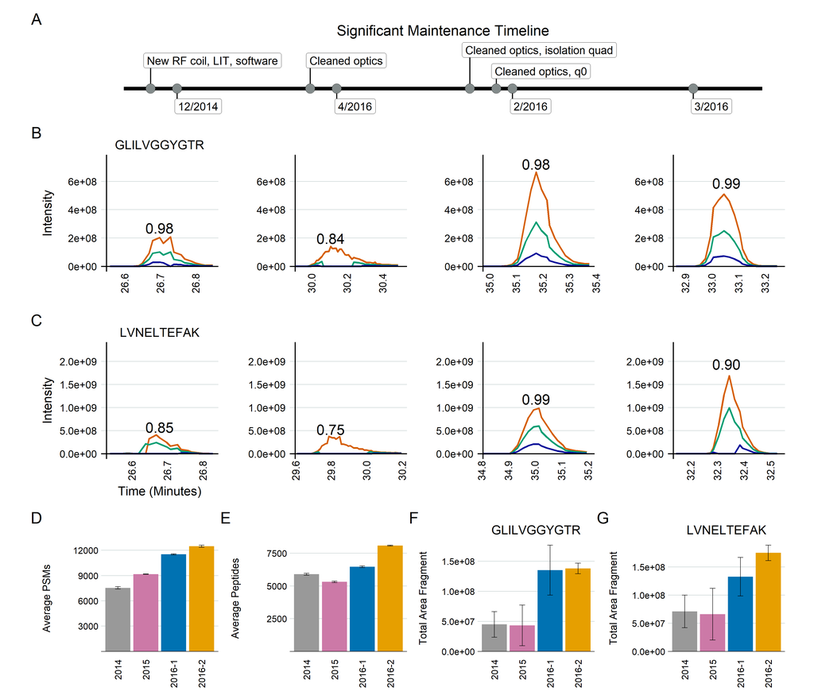

```r
# Print Figure 3
  fig3
```

# Figure 4, Supplemental Figure 1

## Tidying

Merging data and metadata.

$~$

```r
# Select PRTC peptides for figure generation
fig4_YENO1 <- "VNQIGTLSESIK"
figS1_YENO1 <- c("AADALLLK", "VNQIGTLSESIK")
figS1_PRTC <- c("NGFILDGFPR","TASEFDSAIAQDK")

fig4_pa_rt_chrom_grouped <- fig4_pa_rt_chrom %>%
                            rename("Replicate" = "Replicate.Name") %>%
                            group_by(Replicate,Peptide.Modified.Sequence,Fragment.Ion) %>%
                            merge(., fig4_meta, by = c("Replicate", "Group"))


fig4_pa_rt_chrom_grouped_ms2 <- fig4_pa_rt_chrom_grouped %>%
                                filter(Fragment.Ion != "precursor") %>%
                                filter(Fragment.Ion != "precursor [M+1]") %>%
                                filter(Fragment.Ion != "precursor [M+2]")

colnames(fig4_pa_rt_chrom_grouped_ms2)
```

```
##  [1] "Replicate"                       "Group"
##  [3] "Protein"                         "Peptide.Modified.Sequence"
##  [5] "Fragment.Ion"                    "Transition"
##  [7] "Precursor"                       "Product.Mz"
##  [9] "Product.Charge"                  "Transition.Note"
## [11] "Total.Area.Fragment"             "Area"
## [13] "Average.Measured.Retention.Time" "Best.Retention.Time"
## [15] "Min.Start.Time"                  "Max.End.Time"
## [17] "Max.Fwhm"                        "Raw.Times"
## [19] "Raw.Intensities"                 "Interpolated.Times"
## [21] "Interpolated.Intensities"        "File.Name"
## [23] "Acquired.Time"                   "SampleGroup"
## [25] "Replicates"                      "Run.Order"
## [27] "Group.Order"
```

## Functions

**Functions to produce Figure 4**

Defined 2 functions to put together Figure 4:

- fig4_eno_runorder: Peptides plotted in run order. Includes graph title and y-axis title. No x-axis title.
- fig4_eno_group: Peptides plotted in groups. Includes y-axis title. No graph title or x-axis title.

- dataframe:Peak areas, retention times, and chromatography data from DIA sample runs
- peptide_sequence: Sequence of peptides to extract fragment ion area
- fig4ymax: Setting a y-maximum based on the most abundant summed fragment ion peak and adding a buffer

$~$

```r
# Variables to fill-out within the same chunk:
    # Shared variables
        # - legtitle = Legend title (In this case, it's "Fragment")

    # Individual panels
        # - fig4_plottitle = Plot title is the peptide plotted, where needed.
        # - cbPalette = Color palette which attempts to be colorblind-friendly.
            # ^ NOTE: Define separate palette for each panel. Number of colors depends on the number of peptide fragments.
        # - vertical_lines = Points where vertical lines are needed to separate groups in the grouped panel

fig4_eno_runorder <- function(dataframe, peptide_sequence, fig4ymax){

  f4_subdata <- (dataframe %>%
                 filter(Peptide.Modified.Sequence == peptide_sequence) %>%
                 group_by(Fragment.Ion))

  ggplot(f4_subdata,
              aes(group = Fragment.Ion,
                  fill = Fragment.Ion,
                  x = reorder(Replicate, Run.Order),
                  y =  Area)) +

  geom_bar(position="stack", stat="identity", width=0.75) +
               theme_minimal()+
               theme(plot.margin = margin(0, 0, 0, 0, "in"),  # t, r, b, l
                     panel.grid.major.x = element_blank(),
                     panel.grid.major.y = element_line(color="azure3", linewidth = 0.1),
                     panel.grid.minor.x = element_blank(),
                     panel.grid.minor.y = element_blank(),
                     axis.text.x = element_text(size=18, color = "black", angle = 90, margin = margin(t=0, r=0, b=0.5, l=0)),
                     axis.text.y = element_text(size=18, color = "black", margin = margin(t=0, r=0.1, b=0, l=0.1)),
                     axis.title=element_text(size=22, color = "black"),
                     legend.position = "none",
                     plot.title=element_text(size=22, color = "black", hjust = 0.5)
                     ) +
                geom_hline(yintercept=0, linetype="solid", color = "black", linewidth=1) +
                geom_vline(xintercept=0.5, linetype="solid", color = "black", linewidth=1) +
                ggtitle((fig4_plottitle)) +
                scale_fill_manual(values = fig4_cbPalette) +
                scale_y_continuous(name=paste0("Area \n (Run Order)"), limits = c(0,fig4ymax)) +
                scale_x_discrete(name="") +
                annotate("text", x = 16.5, y = (fig4ymax), label = "Run Order", size = 9)
}


fig4_eno_group <- function(dataframe, peptide_sequence, fig4ymax){

  f4_subdata <- (dataframe %>%
                 filter(Peptide.Modified.Sequence == peptide_sequence) %>%
                 group_by(Fragment.Ion))

  ggplot(f4_subdata,
              aes(group = Fragment.Ion,
                  fill = Fragment.Ion,
                  x = reorder(Replicate, Group.Order),
                  y =  Area)) +

  geom_bar(position="stack", stat="identity", width=0.75) +
               theme_minimal()+
               theme(plot.margin = margin(0, 0, 0, 0, "in"),  # t, r, b, l
                     panel.grid.major.x = element_blank(),
                     panel.grid.major.y = element_line(color="azure3", linewidth = 0.1),
                     panel.grid.minor.x = element_blank(),
                     panel.grid.minor.y = element_blank(),
                     axis.text.x = element_text(size=18, color = "black", angle = 90, margin = margin(t=0, r=0, b=0.5, l=0)),
                     axis.text.y = element_text(size=18, color = "black", margin = margin(t=0, r=0.1, b=0, l=0.1)),
                     axis.title=element_text(size=22, color = "black"),
                     legend.position = "none"
                     ) +
                # guides(fill=guide_legend(title=legtitle)) +
                scale_fill_manual(values = fig4_cbPalette) +
                scale_x_discrete(name="Replicates") +
                scale_y_continuous(name=paste0("Area \n (Grouped)"), limits = c(0,fig4ymax)) +
                geom_vline(xintercept=vertical_lines, linetype="dashed", color = "black", linewidth=0.5) +
                geom_hline(yintercept=0, linetype="solid", color = "black", linewidth=1) +
                geom_vline(xintercept=0.5, linetype="solid", color = "black", linewidth=1) +
                annotate("text", x = c(4.5,12.5,20.5,28.5), y = c((fig4ymax),(fig4ymax),(fig4ymax),(fig4ymax)), label = c("1BD","2BD","ISD","STR"), size = 9)
}
```

**Functions to produce Supplementary Figure 1**

- figS1_runorder_title_nox: Peptides plotted in run order. Includes graph title and y-axis title. No x-axis title.
- figS1_group_notitle_nox: Peptides plotted in groups. Includes y-axis title. No graph title or x-axis title.
- figS1_group_notitle: Peptides plotted in groups. Includes y-axis and x-axis title. No graph title.
- figS1_runorder_title_nox_noy: Peptides plotted in run order. No graph title, y-axis title, or x-axis title.
- figS1_group_notitle_nox_noy: Peptides plotted in groups. No graph title, y-axis title, or x-axis title.
- figS1_group_xaxis_noy: Peptides plotted in groups. Includes graph title and x-axis title. No y-axis title.

- dataframe: Peak areas, retention times, and chromatography data from DIA sample runs
- peptide_sequence: Sequence of peptides to extract fragment ion area
- figs1ymax: Setting a y-maximum based on the most abundant summed fragment ion peak and adding a buffer
- figS1_plottitle: Sequence of peptide plotted
- figs1_cbPalette: Color palette

$~$

```r
# Additional vvariable
    # figS1_plottitle:
    # figs1_cbPalette:


# Panel 1 and 3 - Plotted in MS run order. Including plot title. Does not include the shared x-axis title or legend.
figS1_runorder_title_nox <- function(dataframe, peptide_sequence, figs1ymax, figS1_plottitle, figs1_cbPalette){

    s1_subdata <- (dataframe %>%
                 filter(Peptide.Modified.Sequence == peptide_sequence) %>%
                 group_by(Fragment.Ion))

  ggplot(s1_subdata,
              aes(group = Fragment.Ion,
                  fill = Fragment.Ion,
                  x = reorder(Replicate, Run.Order),
                  y =  Area)) +

  geom_bar(position="stack", stat="identity", width=0.75) +
               theme_minimal()+
               theme(plot.margin = margin(0, 0, 0, 0, "in"),  # t, r, b, l
                     panel.grid.major.x = element_blank(),
                     panel.grid.major.y = element_line(color="azure3"),
                     panel.grid.minor.x = element_blank(),
                     panel.grid.minor.y = element_blank(),
                     axis.text.x = element_text(size=18, color = "black", angle = 90, margin = margin(t=0, r=0, b=10, l=0)),
                     axis.text.y = element_text(size=18, color = "black"),
                     axis.title=element_text(size=22, color = "black"),
                     legend.position = "none",
                     plot.title=element_text(size=22, color = "black", hjust = 0.5)
                     ) +
                geom_hline(yintercept=0, linetype="solid", color = "black", linewidth=1) +
                geom_vline(xintercept=0, linetype="solid", color = "black", linewidth=1) +
                ggtitle(figS1_plottitle) +
                scale_fill_manual(values = figs1_cbPalette) +
                scale_y_continuous(name=paste0("Area \n (Run Order)")) +
                scale_x_discrete(name="")  +
                annotate("text", x = 16.5, y = (figs1ymax), label = "Run Order", size = 9)
}


# Panel 2 - Grouped by sample preparation method. Not including plot title, the shared x-axis title, or the shared x-axis title.
figS1_group_notitle_nox <- function(dataframe, peptide_sequence, figs1ymax, figs1_cbPalette){

  s1_subdata <- (dataframe %>%
                 filter(Peptide.Modified.Sequence == peptide_sequence) %>%
                 group_by(Fragment.Ion))

  ggplot(s1_subdata,
              aes(group = Fragment.Ion,
                  fill = Fragment.Ion,
                  x = reorder(Replicate, Group.Order),
                  y =  Area)) +

  geom_bar(position="stack", stat="identity", width=0.75) +
               theme_minimal()+
               theme(plot.margin = margin(0, 0, 0, 0, "in"),  # t, r, b, l
                     panel.grid.major.x = element_blank(),
                     panel.grid.major.y = element_line(color="azure3"),
                     panel.grid.minor.x = element_blank(),
                     panel.grid.minor.y = element_blank(),
                     axis.text.x = element_text(size=18, color = "black", angle = 90, margin = margin(t=0, r=0, b=10, l=0)),
                     axis.text.y = element_text(size=18, color = "black", margin = margin(t=0, r=5, b=0, l=10)),
                     axis.title=element_text(size=22, color = "black"),
                     legend.position = "none",
                     plot.title=element_text(size=22, color = "black", hjust = 0.5)
                     ) +
                # guides(fill=guide_legend(title=legtitle)) +
                scale_fill_manual(values = figs1_cbPalette) +
                scale_x_discrete(name="") +
                scale_y_continuous(name=paste0("Area \n (Grouped)")) +
                geom_vline(xintercept=vertical_lines, linetype="dashed", color = "black", linewidth=0.5) +
                geom_hline(yintercept=0, linetype="solid", color = "black", linewidth=1) +
                geom_vline(xintercept=0, linetype="solid", color = "black", linewidth=1) +
                annotate("text", x = c(4.5,12.5,20.5,28.5), y = c((figs1ymax),(figs1ymax),(figs1ymax),(figs1ymax)), label = c("1BD","2BD","ISD","STR"), size = 9)
}

# Panel 4 - Grouped by sample preparation method. Not including plot title. Includes the shared x-axis title and the legend of plotted fragments.
figS1_group_notitle <- function(dataframe, peptide_sequence, figs1ymax, figs1_cbPalette){

  s1_subdata <- (dataframe %>%
                 filter(Peptide.Modified.Sequence == peptide_sequence) %>%
                 group_by(Fragment.Ion))

  ggplot(s1_subdata,
              aes(group = Fragment.Ion,
                  fill = Fragment.Ion,
                  x = reorder(Replicate, Group.Order),
                  y =  Area)) +

  geom_bar(position="stack", stat="identity", width=0.75) +
               theme_minimal()+
               theme(plot.margin = margin(0, 0, 0, 0, "in"),  # t, r, b, l
                     panel.grid.major.x = element_blank(),
                     panel.grid.major.y = element_line(color="azure3"),
                     panel.grid.minor.x = element_blank(),
                     panel.grid.minor.y = element_blank(),
                     axis.text.x = element_text(size=18, color = "black", angle = 90, margin = margin(t=0, r=0, b=10, l=0)),
                     axis.text.y = element_text(size=18, color = "black", margin = margin(t=0, r=5, b=0, l=10)),
                     axis.title=element_text(size=22, color = "black"),
                     legend.position = "none",
                     plot.title=element_text(size=22, color = "black", hjust = 0.5)
                     ) +
                # guides(fill=guide_legend(title=legtitle)) +
                scale_fill_manual(values = figs1_cbPalette) +
                scale_x_discrete(name="Replicates") +
                scale_y_continuous(name=paste0("Area \n (Grouped)")) +
                geom_vline(xintercept=vertical_lines, linetype="dashed", color = "black", linewidth=0.5) +
                geom_hline(yintercept=0, linetype="solid", color = "black", linewidth=1) +
                geom_vline(xintercept=0, linetype="solid", color = "black", linewidth=1) +
                annotate("text", x = c(4.5,12.5,20.5,28.5), y = c((figs1ymax),(figs1ymax),(figs1ymax),(figs1ymax)), label = c("1BD","2BD","ISD","STR"), size = 9)
}
```

```r
# Panel 1 and 3 - Plotted in MS run order. Including plot title. Does not include the shared x-axis title or legend.
figS1_runorder_title_nox_noy <- function(dataframe, peptide_sequence, figs1ymax, figS1_plottitle, figs1_cbPalette){

  s1_subdata <- (dataframe %>%
                 filter(Peptide.Modified.Sequence == peptide_sequence) %>%
                 group_by(Fragment.Ion))

  ggplot(s1_subdata,
              aes(group = Fragment.Ion,
                  fill = Fragment.Ion,
                  x = reorder(Replicate, Run.Order),
                  y =  Area)) +

  geom_bar(position="stack", stat="identity", width=0.75) +
               theme_minimal()+
               theme(plot.margin = margin(0, 0, 0, 0, "in"),  # t, r, b, l
                     panel.grid.major.x = element_blank(),
                     panel.grid.major.y = element_line(color="azure3"),
                     panel.grid.minor.x = element_blank(),
                     panel.grid.minor.y = element_blank(),
                     axis.text.x = element_text(size=18, color = "black", angle = 90, margin = margin(t=0, r=0, b=10, l=0)),
                     axis.text.y = element_text(size=18, color = "black"),
                     axis.title=element_text(size=22, color = "black"),
                     legend.position = "none",
                     plot.title=element_text(size=22, color = "black", hjust = 0.5)
                     ) +
                geom_hline(yintercept=0, linetype="solid", color = "black", linewidth=1) +
                geom_vline(xintercept=0, linetype="solid", color = "black", linewidth=1) +
                ggtitle(figS1_plottitle) +
                scale_fill_manual(values = figs1_cbPalette) +
                scale_y_continuous(name="") +
                scale_x_discrete(name="")   +
                annotate("text", x = 16.5, y = (figs1ymax), label = "Run Order", size = 9)
}


# Panel 2 - Grouped by sample preparation method. Not including plot title, the shared x-axis title, or the shared x-axis title.
figS1_group_notitle_nox_noy <- function(dataframe, peptide_sequence, figs1ymax, figs1_cbPalette){

  s1_subdata <- (dataframe %>%
                 filter(Peptide.Modified.Sequence == peptide_sequence) %>%
                 group_by(Fragment.Ion))

  ggplot(s1_subdata,
              aes(group = Fragment.Ion,
                  fill = Fragment.Ion,
                  x = reorder(Replicate, Group.Order),
                  y =  Area)) +

  geom_bar(position="stack", stat="identity", width=0.75) +
               theme_minimal()+
               theme(plot.margin = margin(0, 0, 0, 0, "in"),  # t, r, b, l
                     panel.grid.major.x = element_blank(),
                     panel.grid.major.y = element_line(color="azure3"),
                     panel.grid.minor.x = element_blank(),
                     panel.grid.minor.y = element_blank(),
                     axis.text.x = element_text(size=18, color = "black", angle = 90, margin = margin(t=0, r=0, b=10, l=0)),
                     axis.text.y = element_text(size=18, color = "black", margin = margin(t=0, r=5, b=0, l=10)),
                     axis.title=element_text(size=22, color = "black"),
                     legend.position = "none",
                     plot.title=element_text(size=22, color = "black", hjust = 0.5)
                     ) +
                # guides(fill=guide_legend(title=legtitle)) +
                scale_fill_manual(values = figs1_cbPalette) +
                scale_x_discrete(name="") +
                scale_y_continuous(name="") +
                geom_vline(xintercept=vertical_lines, linetype="dashed", color = "black", linewidth=0.5) +
                geom_hline(yintercept=0, linetype="solid", color = "black", linewidth=1) +
                geom_vline(xintercept=0, linetype="solid", color = "black", linewidth=1) +
                annotate("text", x = c(4.5,12.5,20.5,28.5), y = c((figs1ymax),(figs1ymax),(figs1ymax),(figs1ymax)), label = c("1BD","2BD","ISD","STR"), size = 9)
}


# Panel 4 - Grouped by sample preparation method. Not including plot title. Includes the shared x-axis title and the legend of plotted fragments.
figS1_group_xaxis_noy <- function(dataframe, peptide_sequence, figs1ymax, figs1_cbPalette){

  s1_subdata <- (dataframe %>%
                 filter(Peptide.Modified.Sequence == peptide_sequence) %>%
                 group_by(Fragment.Ion))

  ggplot(s1_subdata,
              aes(group = Fragment.Ion,
                  fill = Fragment.Ion,
                  x = reorder(Replicate, Group.Order),
                  y =  Area)) +

  geom_bar(position="stack", stat="identity", width=0.75) +
               theme_minimal()+
               theme(plot.margin = margin(0, 0, 0, 0, "in"),  # t, r, b, l
                     panel.grid.major.x = element_blank(),
                     panel.grid.major.y = element_line(color="azure3"),
                     panel.grid.minor.x = element_blank(),
                     panel.grid.minor.y = element_blank(),
                     axis.text.x = element_text(size=18, color = "black", angle = 90, margin = margin(t=0, r=0, b=10, l=0)),
                     axis.text.y = element_text(size=18, color = "black", margin = margin(t=0, r=5, b=0, l=10)),
                     axis.title=element_text(size=22, color = "black"),
                     legend.position = "none",
                     plot.title=element_text(size=22, color = "black", hjust = 0.5)
                     ) +
                scale_fill_manual(values = figs1_cbPalette) +
                scale_x_discrete(name="Replicates") +
                scale_y_continuous(name="") +
                geom_vline(xintercept=vertical_lines, linetype="dashed", color = "black", linewidth=0.5) +
                geom_hline(yintercept=0, linetype="solid", color = "black", linewidth=1) +
                geom_vline(xintercept=0, linetype="solid", color = "black", linewidth=1) +
                annotate("text", x = c(4.5,12.5,20.5,28.5), y = c((figs1ymax),(figs1ymax),(figs1ymax),(figs1ymax)), label = c("1BD","2BD","ISD","STR"), size = 9)
}
```

Small functions to print fragments plotted and to extract the maximum summed fragment area.

$~$

```r
print_fragments <- function(dataframe, peptide) {

          subdata <- dataframe %>%
                  filter(Peptide.Modified.Sequence == peptide)
                  print(unique(subdata$Fragment.Ion)) }


print_max_area <- function(dataframe, peptide) {

          subdata <- dataframe %>%
                  filter(Peptide.Modified.Sequence == peptide) %>%
                  group_by(Replicate) %>%
                  summarise(replicate = Replicate,
                           summedarea = sum(Area))
                  print(max(subdata$summedarea)) }
```

## Figure 4

Assembling Figure 4

$~$

```r
# Setting additional variables for final plots
    # Shared  variables
      fig4_cbPalette <- c("#000000", "#E69F00", "#56B4E9", "#009E73", "#F0E442", "#0072B2", "#CC79A7","#D55E00", "#000999")
          # One palette since it's the same peptide in both panels

    # Variable only for upper (run order) panel
      fig4_plottitle <- paste0("Yeast Enolase: ",fig4_YENO1)

    # Variable only for lower (grouped) panel
      vertical_lines <- c(8.5, 16.5, 24.5)

# Print maximum area plus a buffer for peptide in figure
print_max_area(fig4_pa_rt_chrom_grouped_ms2,fig4_YENO1)+0.25e8


# Top panel
fig4_top <- fig4_eno_runorder(dataframe = fig4_pa_rt_chrom_grouped_ms2,
                              peptide_sequence = fig4_YENO1,
                              fig4ymax = (print_max_area(fig4_pa_rt_chrom_grouped_ms2,fig4_YENO1)+0.7e8))
#Bottom panel
figS4_bottom <- fig4_eno_group(dataframe = fig4_pa_rt_chrom_grouped_ms2,
                               peptide_sequence = fig4_YENO1,
                               fig4ymax = (print_max_area(fig4_pa_rt_chrom_grouped_ms2,fig4_YENO1)+0.7e8))

# Putting the panels together
fig4_patch <- fig4_top / figS4_bottom

fig4 <- fig4_patch + plot_annotation(tag_levels = 'A') & theme(plot.tag = element_text(size = 6))

# Output Figure 4 as a .svg file.
ggsave(file = paste("output\\",basename,filenamebase,"Figure4.svg", sep=""), plot=fig4, width=15, height=15)

# Output Figure 4 as a .png file.
ggsave(file = paste("output\\",basename,filenamebase,"Figure4.png", sep=""), plot=fig4, width=15, height=15)
```

```
## [1] 1067049598
## [1] 1092049598
## [1] 1067049598
## [1] 1067049598
```

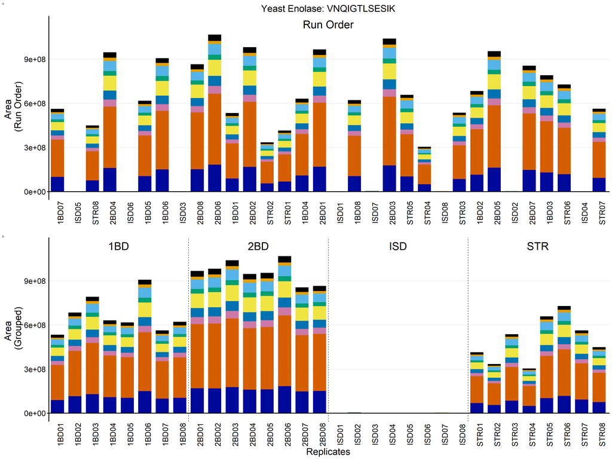

```r
# Print Figure 4
  fig4
```

## Supplemental Figure S1

Assembling Supplementary Figure 1.

$~$

```r
# Shared variable
  vertical_lines <- c(8.5, 16.5, 24.5)

# figS1_YENO1[1]
  # Print fragments for peptide in figure
    print_fragments(fig4_pa_rt_chrom_grouped_ms2,figS1_YENO1[1])
  # Run order
  figS1_pep1_top <- figS1_runorder_title_nox(dataframe = fig4_pa_rt_chrom_grouped_ms2,
                                             peptide_sequence = figS1_YENO1[1],
                                             figs1ymax = (print_max_area(fig4_pa_rt_chrom_grouped_ms2,figS1_YENO1[1])+0.55e8),
                                             figS1_plottitle = paste0("Yeast Enolase: ",figS1_YENO1[1]),
                                             figs1_cbPalette = c("#000000", "#009E73", "#999999","#F0E442", "#0072B2", "#D55E00", "#CC79A7"))
  # Grouped by digestion
  figS1_pep1_bottom <- figS1_group_notitle_nox(dataframe = fig4_pa_rt_chrom_grouped_ms2,
                                               peptide_sequence = figS1_YENO1[1],
                                               figs1ymax = (print_max_area(fig4_pa_rt_chrom_grouped_ms2,figS1_YENO1[1])+0.55e8),
                                               figs1_cbPalette = c("#000000", "#009E73", "#999999","#F0E442", "#0072B2", "#D55E00", "#CC79A7"))

# figS1_YENO1[2]
  # Print fragments for peptide in figure
    print_fragments(fig4_pa_rt_chrom_grouped_ms2,figS1_YENO1[2])
  # Run order
  figS1_pep2_top <- figS1_runorder_title_nox_noy(dataframe = fig4_pa_rt_chrom_grouped_ms2,
                                                 peptide_sequence = figS1_YENO1[2],
                                                 figs1ymax = (print_max_area(fig4_pa_rt_chrom_grouped_ms2,figS1_YENO1[2])+0.7e8),
                                                 figS1_plottitle = paste0("Yeast Enolase: ",figS1_YENO1[2]),
                                                 figs1_cbPalette = c("#000000", "#E69F00", "#56B4E9", "#009E73", "#F0E442",
                                                                     "#0072B2", "#CC79A7","#D55E00", "#000999"))
  # Grouped by digestion
  figS1_pep2_bottom <- figS1_group_notitle_nox_noy(dataframe = fig4_pa_rt_chrom_grouped_ms2,
                                                   peptide_sequence = figS1_YENO1[2],
                                                   figs1ymax = (print_max_area(fig4_pa_rt_chrom_grouped_ms2,figS1_YENO1[2])+0.7e8),
                                                   figs1_cbPalette = c("#000000", "#E69F00", "#56B4E9", "#009E73", "#F0E442",
                                                                     "#0072B2", "#CC79A7","#D55E00", "#000999"))

# figS1_PRTC[1]
  # Print fragments for peptide in figure
    print_fragments(fig4_pa_rt_chrom_grouped_ms2,figS1_PRTC[1])
  # Run order
  figS1_pep3_top <- figS1_runorder_title_nox(dataframe = fig4_pa_rt_chrom_grouped_ms2,
                                             peptide_sequence = figS1_PRTC[1],
                                             figs1ymax = (print_max_area(fig4_pa_rt_chrom_grouped_ms2,figS1_PRTC[1])+0.65e9),
                                             figS1_plottitle = paste0("PRTC: ",figS1_PRTC[1]),
                                             figs1_cbPalette = c("#000000", "#009E73", "#999999","#F0E442",
                                                                 "#0072B2", "#D55E00", "#CC79A7"))
  # Grouped by digestion
  figS1_pep3_bottom <- figS1_group_notitle(dataframe = fig4_pa_rt_chrom_grouped_ms2,
                                           peptide_sequence = figS1_PRTC[1],
                                           figs1ymax = (print_max_area(fig4_pa_rt_chrom_grouped_ms2,figS1_PRTC[1])+0.65e9),
                                           figs1_cbPalette = c("#000000", "#009E73", "#999999","#F0E442",
                                                                 "#0072B2", "#D55E00", "#CC79A7"))

# figS1_PRTC[2]
  # Print fragments for peptide in figure
    print_fragments(fig4_pa_rt_chrom_grouped_ms2,figS1_PRTC[2])
  # Run order
  figS1_pep4_top <- figS1_runorder_title_nox_noy(dataframe = fig4_pa_rt_chrom_grouped_ms2,
                                                 peptide_sequence = figS1_PRTC[2],
                                                 figs1ymax = (print_max_area(fig4_pa_rt_chrom_grouped_ms2,figS1_PRTC[2])+0.3e9),
                                                 figS1_plottitle = paste0("PRTC: ",figS1_PRTC[2]),
                                                 figs1_cbPalette = c("#000000","#999999", "#E69F00", "#56B4E9", "#009E73",
                                                                     "#F0E442", "#0072B2", "#CC79A7","#D55E00", "#000999"))
  # Grouped by digestion
  figS1_pep4_bottom <- figS1_group_xaxis_noy(dataframe = fig4_pa_rt_chrom_grouped_ms2,
                                             peptide_sequence = figS1_PRTC[2],
                                             figs1ymax = (print_max_area(fig4_pa_rt_chrom_grouped_ms2,figS1_PRTC[2])+0.3e9),
                                             figs1_cbPalette = c("#000000","#999999", "#E69F00", "#56B4E9", "#009E73",
                                                                 "#F0E442", "#0072B2", "#CC79A7","#D55E00", "#000999"))

# Setting up layout for final figure to assemble all panels of Supplementary Figure S1. Order important for proper annotations.
  figS1_layout <- c(
      area(t = 1, l = 1, b = 1, r = 1),
      area(t = 1, l = 2, b = 1, r = 2),
      area(t = 2, l = 1, b = 2, r = 1),
      area(t = 2, l = 2, b = 2, r = 2),
      area(t = 3, l = 1, b = 3, r = 1),
      area(t = 3, l = 2, b = 3, r = 2),
      area(t = 4, l = 1, b = 4, r = 1),
      area(t = 4, l = 2, b = 4, r = 2)
      )

# Generating patchwork of final Supplementary Figure S1.
    figS1 <- (figS1_pep1_top + figS1_pep2_top + figS1_pep1_bottom + figS1_pep2_bottom + figS1_pep3_top + figS1_pep4_top + figS1_pep3_bottom + figS1_pep4_bottom + plot_layout(design = figS1_layout) + plot_annotation(tag_levels = 'A') & theme(plot.tag = element_text(size = 28)))

# Export Supplementary Figure 1 as .svg file
  ggsave(file = paste("output\\",basename,filenamebase,"FigureS1.svg", sep=""), plot=figS1, width=20, height=30)

# Export Supplementary Figure 1 as .png file
  ggsave(file = paste("output\\",basename,filenamebase,"FigureS1.png", sep=""), plot=figS1, width=20, height=30)
```

```
## [1] "y6" "y5" "y4" "y3" "y2"
## [1] 303843838
## [1] 303843838
## [1] "y9"  "y5"  "y8"  "y4"  "y10" "y7"  "y3"  "y6"  "y2"
## [1] 1067049598
## [1] 1067049598
## [1] "y5" "y8" "y4" "y7" "y3" "y6" "y2"
## [1] 5302435984
## [1] 5302435984
##  [1] "y4"  "y3"  "y2"  "y11" "y9"  "y10" "y8"  "y7"  "y6"  "y5"
## [1] 2770972416
## [1] 2770972416
```

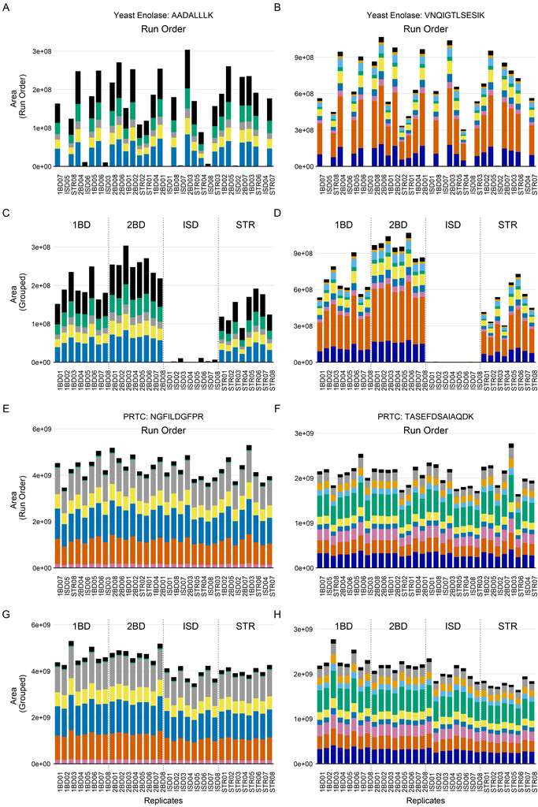

```r
# Print Supplementary Figure 1
  figS1
```

# Figure 5

## Tidying

Narrowing data to only consider fragment ions and selecting target peptides (Yeast Enolase: AVDDFLISLDGTANK, PRTC: GLILVGGYGTR).

$~$

```r
# Select Yeast enolase and PRTC peptides for figure generation
fig5_YENO1 <- "AVDDFLISLDGTANK"
fig5_PRTC <- "GLILVGGYGTR"

fig5_pa_rt_chrom_meta <- fig5_pa_rt_chrom %>%
                            rename("Replicate" = "Replicate.Name") %>%
                            merge(., fig5_meta, by = c("Replicate", "Group"))


fig5_pa_rt_chrom_meta_ms2 <- fig5_pa_rt_chrom_meta %>%
                                filter(Fragment.Ion != "precursor") %>%
                                filter(Fragment.Ion != "precursor [M+1]") %>%
                                filter(Fragment.Ion != "precursor [M+2]")
```

## Functions

**Functions to produce Figure 5: Plotting Fragment Ion Intensities**

Function requires a dataframe, peptide sequence to plot, and a subtitle that is used to add a title to the intensity panel. Used the peptide sequence.

- dataframe: Peak areas, retention times, and chromatography data from DIA sample runs
- peptide: Sequence of peptides to extract fragment ion area
- fig5_subtitle: Title showing sequence of peptide
- fig5_cbPalette: Color palette

$~$

```r
fragment_intensity_rep_ylabel <- function(dataframe, peptide, fig5_subtitle, fig5_cbPalette){

  fig5top_subdata <- (dataframe %>%
                      filter(Peptide.Modified.Sequence == peptide))

fragment_intensity_plot <- (ggplot(fig5top_subdata,
                           aes(group = Fragment.Ion,
                              fill = Fragment.Ion,
                              x = factor(Replicate),
                              y =  Area)) +

                           geom_bar(position="stack", stat="identity", width=0.85) +
                           theme_minimal()+
                           theme(plot.margin = margin(t = 0.3, r = 0.1, b = 0.1, l = 0.4, unit = "in"),
                                 panel.grid.major.x = element_blank(),
                                 panel.grid.major.y = element_line(color="azure3"),
                                 panel.grid.minor.x = element_blank(),
                                 panel.grid.minor.y = element_blank(),
                                 axis.text.x = element_text(size=18, color = "black", margin = margin(t=0, r=0, b=10, l=0)),
                                 axis.text.y = element_text(size=18, color = "black"),
                                 axis.title.x = element_text(size = 2, color = "black"),
                                 axis.title.y = element_text(size = 22, color = "black"),
                                 legend.position = "none",
                                 plot.title=element_text(size=22, color = "black", hjust = 0.5)
                                 ) +
                            ggtitle(fig5_subtitle) +
                            geom_hline(yintercept=0, linetype="solid", color = "black", linewidth=1) +
                            geom_vline(xintercept=0.5, linetype="solid", color = "black", linewidth=1) +
                            scale_fill_manual(values = fig5_cbPalette) +
                            scale_x_discrete(name="") +
                            scale_y_continuous(name="Area"))
fragment_intensity_plot
}


fragment_intensity_rep_nolabel <- function(dataframe, peptide, fig5_subtitle, fig5_cbPalette){

  fig5top_subdata <- (dataframe %>%
                      filter(Peptide.Modified.Sequence == peptide))

fragment_intensity_plot <- (ggplot(fig5top_subdata,
                           aes(group = Fragment.Ion,
                              fill = Fragment.Ion,
                              x = factor(Replicate),
                              y =  Area)) +

                           geom_bar(position="stack", stat="identity", width=0.85) +
                           theme_minimal()+
                           theme(plot.margin = margin(t = 0.3, r = 0.1, b = 0.1, l = 0.2, unit = "in"),
                                 panel.grid.major.x = element_blank(),
                                 panel.grid.major.y = element_line(color="azure3"),
                                 panel.grid.minor.x = element_blank(),
                                 panel.grid.minor.y = element_blank(),
                                 axis.text.x = element_text(size=18, color = "black",  margin = margin(t=0, r=0, b=10, l=0)),
                                 axis.text.y = element_text(size=18, color = "black"),
                                 axis.title.x = element_text(size = 2, color = "black"),
                                 axis.title.y = element_text(size = 22, color = "black"),
                                 legend.position = "none",
                                 plot.title=element_text(size=22, color = "black", hjust = 0.5)
                                 ) +
                            ggtitle(fig5_subtitle) +
                            geom_hline(yintercept=0, linetype="solid", color = "black", linewidth=1) +
                            geom_vline(xintercept=0.5, linetype="solid", color = "black", linewidth=1) +
                            scale_fill_manual(values = fig5_cbPalette) +
                            scale_x_discrete(name="") +
                            scale_y_continuous(name=" "))
fragment_intensity_plot
  }
```

**Functions to produce Figure 5: Plotting Chromatograms of Fragment Ions**

Defined 3 functions to put together Figure 5:

- chromatogram_assigned_peak: Chromatogram with axis titles
- chromatogram_assigned_peak_nolabel: Chromatogram without axis titles
- chromatogram_assigned_peak_zoom: Removed axis titles and zoomed in closer on peak

All 3 functions require a dataframe, sample replicate, peptide sequence to plot, measured time, measured intensity, y-axis maximum, x-axis minimum buffer (Distance between peak edge), and x-axis maximum buffer (Distance between peak edge).

- dataframe: Peak areas, retention times, and chromatography data from DIA sample runs
- replicate_name: Sample replicate to extract chromatograms
- peptide: Peptide sequence to plot
- time_col: Measured times
- intensity_col: Intensity at the measured times
- y_axis_max: Setting a y-axis maximum based on the peak apex wth a buffer
- x_min_buffer_5: Setting a buffer between early peak edge and y-axis
- x_max_buffer_5: Setting a buffer between late peak edge and graph edge
- fig5_cbPalette: Color palette

$~$

```r
chromatogram_assigned_peak <- function(dataframe, replicate_name, peptide, time_col, intensity_col, y_axis_max, x_min_buffer_5, x_max_buffer_5, fig5_cbPalette){

  subdata <- dataframe %>%
             filter(Replicate == replicate_name) %>%
             filter(Peptide.Modified.Sequence == peptide) %>%
             rename("Time" = time_col,
                    "Intensity" = intensity_col)

    subdata_chromatogram <- subdata %>%
                     separate_longer_delim(., cols = c("Time", "Intensity"), delim = ",") %>%
                     group_by(Fragment.Ion)

  subdata_chromatogram <- transform(subdata_chromatogram, Time = as.numeric(Time))
  subdata_chromatogram <- transform(subdata_chromatogram, Intensity = as.numeric(Intensity))

chrom_x_min <- (min(subdata_chromatogram$Best.Retention.Time) - x_min_buffer_5)
chrom_x_max <- (max(subdata_chromatogram$Best.Retention.Time) + x_max_buffer_5)

chromatogram_plot  <-  (ggplot(subdata_chromatogram,
              aes(group = Fragment.Ion,
                  color = Fragment.Ion,
                  x = Time,
                  y =  Intensity)) +

  geom_line(linewidth = 1.5) +
               theme_minimal()+
               theme(plot.margin = margin(t = 0.3, r = 0.1, b = 0.1, l = 0.4, unit = "in"),
                    panel.grid.major.x = element_blank(),
                     panel.grid.major.y = element_line(color="azure3"),
                     panel.grid.minor.x = element_blank(),
                     panel.grid.minor.y = element_blank(),
                     axis.text.x = element_text(size=18, color = "black", angle = 90, margin = margin(t=0, r=0, b=10, l=0)),
                     axis.text.y = element_text(size=18, color = "black", margin = margin(t=0, r=5, b=0, l=10)),
                     axis.title.x = element_text(size = 22, color = "black", hjust = 1),
                     axis.title.y = element_text(size = 22, color = "black"),
                     legend.position = "none"
                     ) +
                scale_color_manual(values = fig5_cbPalette) +
                scale_x_continuous(name="Time (Minutes)", limits=c(chrom_x_min, chrom_x_max)) +
                scale_y_continuous(name="Intensity", limits=c(0, y_axis_max)) +
                geom_hline(yintercept=0, linetype="solid", color = "black", linewidth=1) +
                geom_vline(xintercept=chrom_x_min, linetype="solid", color = "black", linewidth=1))

chromatogram_plot

}



chromatogram_assigned_peak_nolabel <- function(dataframe, replicate_name, peptide, time_col, intensity_col, y_axis_max, x_min_buffer_5, x_max_buffer_5, fig5_cbPalette){

  subdata <- dataframe %>%
             filter(Replicate == replicate_name) %>%
             filter(Peptide.Modified.Sequence == peptide) %>%
             rename("Time" = time_col,
                    "Intensity" = intensity_col)

    subdata_chromatogram <- subdata %>%
                     separate_longer_delim(., cols = c("Time", "Intensity"), delim = ",") %>%
                     group_by(Fragment.Ion)

  subdata_chromatogram <- transform(subdata_chromatogram, Time = as.numeric(Time))
  subdata_chromatogram <- transform(subdata_chromatogram, Intensity = as.numeric(Intensity))

chrom_x_min <- (min(subdata_chromatogram$Best.Retention.Time) - x_min_buffer_5)
chrom_x_max <- (max(subdata_chromatogram$Best.Retention.Time) + x_max_buffer_5)

chromatogram_plot  <-  (ggplot(subdata_chromatogram,
              aes(group = Fragment.Ion,
                  color = Fragment.Ion,
                  x = Time,
                  y =  Intensity)) +

  geom_line(linewidth = 1.5) +
               theme_minimal()+
               theme(plot.margin = margin(t = 0.3, r = 0.1, b = 0.1, l = 0.2, unit = "in"),
                     panel.grid.major.x = element_blank(),
                     panel.grid.major.y = element_line(color="azure3"),
                     panel.grid.minor.x = element_blank(),
                     panel.grid.minor.y = element_blank(),
                     axis.text.x = element_text(size=18, color = "black", angle = 90, margin = margin(t=0, r=0, b=10, l=0)),
                     axis.text.y = element_text(size=18, color = "black", margin = margin(t=0, r=5, b=0, l=10)),
                     axis.title.x = element_text(size = 22, color = "black"),
                     axis.title.y = element_text(size = 22, color = "black"),
                     legend.position = "none"
                     ) +
                scale_color_manual(values = fig5_cbPalette) +
                scale_x_continuous(name=" ", limits=c(chrom_x_min, chrom_x_max)) +
                scale_y_continuous(name=" ", limits=c(0, y_axis_max)) +
                geom_hline(yintercept=0, linetype="solid", color = "black", linewidth=1) +
                geom_vline(xintercept=chrom_x_min, linetype="solid", color = "black", linewidth=1))

chromatogram_plot

}



chromatogram_assigned_peak_zoom <- function(dataframe, replicate_name, peptide, time_col, intensity_col, y_axis_max, x_min_buffer_5, x_max_buffer_5, fig5_cbPalette){

  subdata <- dataframe %>%
             filter(Replicate == replicate_name) %>%
             filter(Peptide.Modified.Sequence == peptide) %>%
             rename("Time" = time_col,
                    "Intensity" = intensity_col)

    subdata_chromatogram <- subdata %>%
                     separate_longer_delim(., cols = c("Time", "Intensity"), delim = ",") %>%
                     group_by(Fragment.Ion)

  subdata_chromatogram <- transform(subdata_chromatogram, Time = as.numeric(Time))
  subdata_chromatogram <- transform(subdata_chromatogram, Intensity = as.numeric(Intensity))

chrom_x_min <- (min(subdata_chromatogram$Best.Retention.Time) - x_min_buffer_5)
chrom_x_max <- (max(subdata_chromatogram$Best.Retention.Time) + x_max_buffer_5)

chromatogram_plot  <-  (ggplot(subdata_chromatogram,
              aes(group = Fragment.Ion,
                  color = Fragment.Ion,
                  x = Time,
                  y =  Intensity)) +

  geom_line(linewidth = 1.5) +
               theme_minimal()+
               theme(panel.grid.major.x = element_blank(),
                     panel.grid.major.y = element_line(color="azure3"),
                     panel.grid.minor.x = element_blank(),
                     panel.grid.minor.y = element_blank(),
                     axis.text.x = element_text(size=18, color = "black", angle = 90, margin = margin(t=0, r=0, b=10, l=0)),
                     axis.text.y = element_text(size=18, color = "black", margin = margin(t=0, r=5, b=0, l=10)),
                     axis.title = element_blank(),
                     legend.position = "none"
                     ) +
                scale_color_manual(values = fig5_cbPalette) +
                scale_x_continuous(name="Time (Minutes)", limits=c(chrom_x_min, chrom_x_max)) +
                scale_y_continuous(name="Intensity", limits=c(0, y_axis_max)) +
                geom_hline(yintercept=0, linetype="solid", color = "black", linewidth=1) +
                geom_vline(xintercept=chrom_x_min, linetype="solid", color = "black", linewidth=1))

chromatogram_plot

}
```

**Functions to produce Figure 5: Retention Time of Fragment Ions**

- dataframe: Peak areas, retention times, and chromatography data from DIA sample runs
- peptide: Peptide to extract retention times for.
- late_replicate_name: Replicate with later elution time time to set y-axis boundaries.
- early_replicate_name: Replicate with an earlier elution time to set y-axis boundaries.
- fig5_cbPalette: Color palette

$~$

```r
rt_fragments <- function(dataframe, peptide, late_replicate_name, early_replicate_name, fig5_cbPalette){

  subdata_rt <- dataframe %>%
                filter(Peptide.Modified.Sequence == peptide)

subdata_early_replicate <- subdata_rt %>%
                     filter(Replicate == early_replicate_name)

subdata_late_replicate <- subdata_rt %>%
                     filter(Replicate == late_replicate_name)


rt_y_min <- (min(subdata_early_replicate$Min.Start.Time) - 3)
rt_y_max <- (max(subdata_late_replicate$Max.End.Time) + 3)


print(paste0("RT min: ", rt_y_min, " RT max: ", rt_y_max))

transition_rt_plot  <-  (ggplot() +
              geom_linerange(subdata_rt,
              mapping = aes(group = interaction(Replicate, Fragment.Ion),
                  color = Fragment.Ion,
                  x = factor(Replicate),
                  ymin = Min.Start.Time,
                  ymax = Max.End.Time), position = position_dodge2(width = 0.85, preserve = "single", padding = 0.2), linewidth = 2) +

               theme_minimal()+
               theme(panel.grid.major.x = element_blank(),
                     panel.grid.major.y = element_line(color="azure3"),
                     panel.grid.minor.x = element_blank(),
                     panel.grid.minor.y = element_blank(),
                     axis.text.x = element_text(size=18, color = "black", margin = margin(t=0, r=0, b=10, l=0)),
                     axis.text.y = element_text(size=18, color = "black", margin = margin(t=0, r=5, b=0, l=10)),
                     axis.title = element_text(size=22, color = "black"),
                     legend.position = "none",

                     plot.title=element_text(size=22, color = "black", hjust = 0.5)
                     ) +
                scale_color_manual(values = fig5_cbPalette) +
                scale_x_discrete(name="Replicate") +
                scale_y_continuous(name=paste0("Time (Minutes)"), limits=c(rt_y_min, rt_y_max)) +
                geom_hline(yintercept=rt_y_min, linetype="solid", color = "black", linewidth=1) +# )#+
                geom_vline(xintercept=0.5, linetype="solid", color = "black", linewidth=1))

transition_rt_plot

}
```

## Figure 5

To finish Figure 5, moved the x-axis labels “Time (Minutes)” to the center of panels C-D and E-F by moving them in Inkscape:

- x-axis label for panel C-D: Move to the right 130 pixels
- x-axis label for panel #-F:Move to the right 130 pixels

$~$

```r
# Shared parameters
fig5_panel_w <- 5
fig5_panel_h <- 5
fig5_zoom_w <- 5
fig5_zoom_h <- 5


print_fragments(dataframe = fig5_pa_rt_chrom_meta_ms2, peptide = fig5_YENO1)
print_fragments(dataframe = fig5_pa_rt_chrom_meta_ms2, peptide = fig5_PRTC)

# Plotting the fragment intensities of one yeast enolase peptide and one PRTC peptide
fig5_yeno1_intensity <- fragment_intensity_rep_ylabel(dataframe = fig5_pa_rt_chrom_meta_ms2,
                                                      peptide = fig5_YENO1,
                                                      fig5_subtitle = paste0("Yeast Enolase 1:",fig5_YENO1),
                                                      fig5_cbPalette =  c("#000000","#999999", "#E69F00", "#56B4E9", "#009E73", "#F0E442",
                                                                          "#0072B2", "#CC79A7","#D55E00", "#000999","#FF0000", "#555555"))

# Plotting the fragment intensities of one PRTC peptide
fig5_prtc_intensity <- fragment_intensity_rep_nolabel(dataframe = fig5_pa_rt_chrom_meta_ms2,
                                                      peptide = fig5_PRTC,
                                                      fig5_subtitle = paste0("PRTC:",fig5_PRTC),
                                                      fig5_cbPalette = c("#000000","#999999", "#E69F00", "#56B4E9", "#009E73", "#F0E442",
                                                                         "#0072B2", "#CC79A7","#D55E00", "#000999","#FF0000", "#555555"))




# Setting the y-axis maximums for the chromatogram plots of one yeast enolase peptide and one PRTC peptide
fig5_yeno1_yax <- (1.3e8)
fig5_prtc_yax <- (4.5e8)


# Plotting the raw intensity and raw time columns to generate a chromatogram of one yeast enolase peptide.
  # Sample 7
  fig5_7_yeno1_raw <- chromatogram_assigned_peak(dataframe = fig5_pa_rt_chrom_meta_ms2,
                                                 replicate_name = "7",
                                                 peptide = fig5_YENO1,
                                                 time_col = "Raw.Times",
                                                 intensity_col = "Raw.Intensities",
                                                 y_axis_max = fig5_yeno1_yax,
                                                 x_min_buffer_5 = 0.75,
                                                 x_max_buffer_5 = 1,
                                                 fig5_cbPalette = c("#000000","#999999", "#E69F00", "#56B4E9", "#009E73", "#F0E442",
                                                                    "#0072B2", "#CC79A7","#D55E00", "#000999","#FF0000", "#555555"))
  # Sample 9, which is a re-injection of Sample 7.
  fig5_9_yeno1_raw <- chromatogram_assigned_peak_nolabel(dataframe = fig5_pa_rt_chrom_meta_ms2,
                                                         replicate_name = "9",
                                                         peptide = fig5_YENO1,
                                                         time_col = "Raw.Times",
                                                         intensity_col = "Raw.Intensities",
                                                         y_axis_max = fig5_yeno1_yax,
                                                         x_min_buffer_5 = 0.5,
                                                         x_max_buffer_5 = 0.5,
                                                         fig5_cbPalette = c("#000000","#999999", "#E69F00", "#56B4E9", "#009E73", "#F0E442",
                                                                            "#0072B2", "#CC79A7","#D55E00", "#000999","#FF0000", "#555555"))
  # Sample 7, zoomed in for better visualization.
  fig5_7_yeno1_zoom_raw <- chromatogram_assigned_peak_zoom(dataframe = fig5_pa_rt_chrom_meta_ms2,
                                                           replicate_name = "7",
                                                           peptide = fig5_YENO1,
                                                           time_col = "Raw.Times",
                                                           intensity_col = "Raw.Intensities",
                                                           y_axis_max = (8e6),
                                                           x_min_buffer_5 = 0.75,
                                                           x_max_buffer_5 = 1,
                                                           fig5_cbPalette = c("#000000","#999999", "#E69F00", "#56B4E9", "#009E73", "#F0E442",
                                                                              "#0072B2", "#CC79A7","#D55E00", "#000999","#FF0000", "#555555"))



# Plotting the raw intensity and raw time columns to generate a chromatogram of one PRTC peptide.
  # Sample 7
  fig5_7_prtc_raw <- chromatogram_assigned_peak(dataframe = fig5_pa_rt_chrom_meta_ms2,
                                                replicate_name = "7",
                                                peptide = fig5_PRTC,
                                                time_col = "Raw.Times",
                                                intensity_col = "Raw.Intensities",
                                                y_axis_max = fig5_prtc_yax,
                                                x_min_buffer_5 = 0.75,
                                                x_max_buffer_5 = 1,
                                                fig5_cbPalette = c("#000000","#999999", "#E69F00", "#56B4E9", "#009E73", "#F0E442", "#0072B2",
                                                                   "#CC79A7","#D55E00", "#000999","#FF0000", "#555555"))

  # Sample 9, which is a re-injection of Sample 7.
  fig5_9_prtc_raw <- chromatogram_assigned_peak_nolabel(dataframe = fig5_pa_rt_chrom_meta_ms2,
                                                        replicate_name = "9",
                                                        peptide = fig5_PRTC,
                                                        time_col = "Raw.Times",
                                                        intensity_col = "Raw.Intensities",
                                                        y_axis_max = fig5_prtc_yax,
                                                        x_min_buffer_5 = 0.7,
                                                        x_max_buffer_5 = 0.7,
                                                        fig5_cbPalette = c("#000000","#999999", "#E69F00", "#56B4E9", "#009E73", "#F0E442",
                                                                           "#0072B2", "#CC79A7","#D55E00", "#000999","#FF0000", "#555555"))

  # Sample 7, zoomed in for better visualization.
  fig5_7_prtc_zoom_raw <- chromatogram_assigned_peak_zoom(dataframe = fig5_pa_rt_chrom_meta_ms2,
                                                          replicate_name = "7",
                                                          peptide = fig5_PRTC,
                                                          time_col = "Raw.Times",
                                                          intensity_col = "Raw.Intensities",
                                                          y_axis_max = (11E6),
                                                          x_min_buffer_5 = 0.75,
                                                          x_max_buffer_5 = 1,
                                                          fig5_cbPalette = c("#000000","#999999", "#E69F00", "#56B4E9", "#009E73", "#F0E442",
                                                                             "#0072B2", "#CC79A7","#D55E00", "#000999","#FF0000", "#555555"))


# Formatting both of the inset plots to not have a letter label in the final patchwork figure
  fig5_7_yeno1_combined <- fig5_7_yeno1_raw + inset_element(fig5_7_yeno1_zoom_raw, 0.4, 0.4, 1, 1, align_to = 'full', ignore_tag = FALSE)
  fig5_7_prtc_combined <- fig5_7_prtc_raw + inset_element(fig5_7_prtc_zoom_raw, 0.4, 0.4, 1, 1, align_to = 'full', ignore_tag = FALSE)


# Plotting retention times of fragments
  # One yeast enolase peptide
  fig5_7_yeno_rt <- rt_fragments(dataframe = fig5_pa_rt_chrom_meta_ms2,
                                 peptide = fig5_YENO1,
                                 late_replicate_name = 7,
                                 early_replicate_name = 1,
                                 fig5_cbPalette = c("#000000","#999999", "#E69F00", "#56B4E9", "#009E73", "#F0E442",
                                                    "#0072B2", "#CC79A7","#D55E00", "#000999","#FF0000", "#555555"))

  # One PRTC peptide.early_replicate_name
  fig5_7_prtc_rt <- rt_fragments(dataframe = fig5_pa_rt_chrom_meta_ms2,
                                 fig5_PRTC,
                                 late_replicate_name = 7,
                                 early_replicate_name = 1,
                                 fig5_cbPalette = c("#000000","#999999", "#E69F00", "#56B4E9", "#009E73", "#F0E442",
                                                    "#0072B2", "#CC79A7","#D55E00", "#000999","#FF0000", "#555555"))

##  [1] "y5"  "y13" "y4"  "y12" "y3"  "y11" "y2"  "y10" "y9"  "y8"  "y7"  "y6"
## [1] "y9" "y8" "y7" "y6" "y5" "y4" "y3" "y2"
## [1] "RT min: 64.9 RT max: 83.72"
## [1] "RT min: 52.72 RT max: 70.95"
```

**Figure 5**

Assembling the fragment intensities, chromatograms, and retention times of Sample 7 and its re-injection, denoted Sample 9.

$~$

```r
# Using patchwork package to put the semi-final figure together
    fig5_layout <- c(
      area(t = 1, l = 1, b = 1, r = 2),
      area(t = 1, l = 3, b = 1, r = 4),
      area(t = 2, l = 1, b = 2, r = 1),
      area(t = 2, l = 2, b = 2, r = 2),
      area(t = 2, l = 3, b = 2, r = 3),
      area(t = 2, l = 4, b = 2, r = 4),
      area(t = 3, l = 1, b = 3, r = 2),
      area(t = 3, l = 3, b = 3, r = 4)
      )

fig5 <- (fig5_yeno1_intensity + fig5_prtc_intensity + fig5_7_yeno1_combined + fig5_9_yeno1_raw + fig5_7_prtc_combined + fig5_9_prtc_raw + fig5_7_yeno_rt + fig5_7_prtc_rt + plot_layout(design = fig5_layout) + plot_annotation(tag_levels = list(c("A", "B", "C", "", "D", "E", "", "F", "G", "H"))) & theme(plot.tag.position = c(0, 1), plot.tag = element_text(size = 46, face = 'bold')))

  ggsave(file = paste("output\\",basename,filenamebase,"Figure5.svg", sep=""), plot=fig5, width=(25), height=(20))

##############################################################################################################################
##############################################################################################################################
##
##    To finish figure, move "Replicate" x-axis labels to the center of panels C-D and E-F by moving
##
##    - Label for panel C-D: Move to the right 130 pixels
##    - Label for panel #-F:Move to the right 130 pixels
```

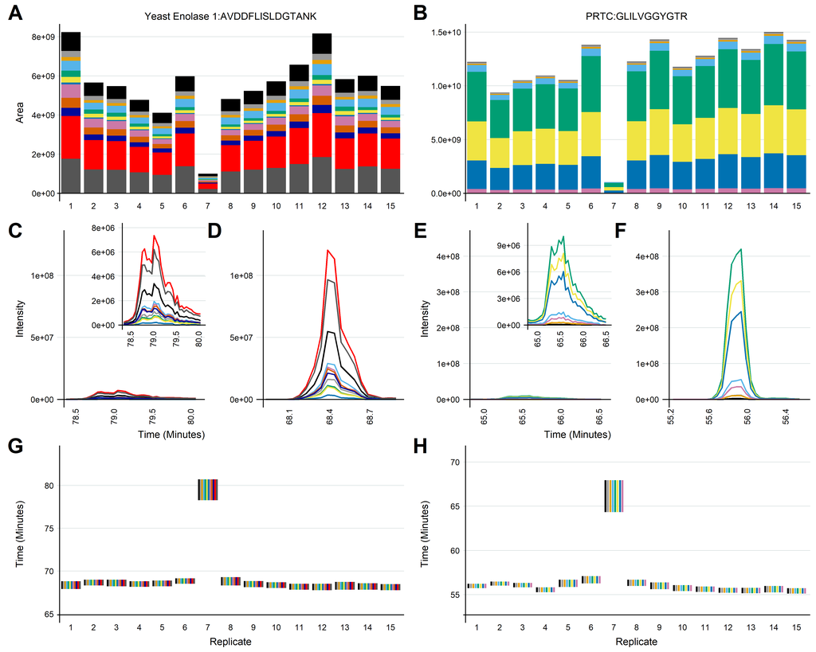

```r
# Print Figure 5 before manual movement of labels in Inkscape.
  fig5
```

# Figure 6

## Tidying

Merged system suitability (SS) data from PRM runs and internal quality control (IQC) data from sample DIA runs.

$~$

```r
# Merging metadata and sample data
SS_data <- full_join(SS_TAF, SS_meta, by = "File.Name")

IQC_data <- full_join(IQC_TAF, IQC_meta, by = "File.Name")

# Merging PRM and DIA data
fig6_replicates <- rbind(SS_data, IQC_data)

fig6_replicates <- fig6_replicates %>%
                   rename("Abbreviation_Skyline" = "Replicate")

# Generating rows of "spacers" to merge with the dataframe of the total area fragments from system suitability (PRM) runs and the internal quality controls from sample (DIA) runs.
row_num_fig6_reps <- nrow(fig6_replicates)

fig6_spacer_temp <- fig6_replicates %>%
                    .[-(1:row_num_fig6_reps),]


    fig6_spacer_1 <- fig6_spacer_temp %>%
                        add_row("Protein.Name" = "qc|PRTC|PRTC_Thermo",
                               "Total.Area.Fragment" = NA,
                               "Peptide.Sequence" = "NGFILDGFPR",
                               "File.Name" = "Spacer.raw",
                               "Group" = "SS",
                               "Abbreviation_Skyline" = "Spacer",
                               "Batch" = "spacer",
                               "ForFigure" = "True")


    fig6_spacer_2 <- fig6_spacer_temp %>%
                        add_row("Protein.Name" = "qc|PRTC|PRTC_Thermo",
                               "Total.Area.Fragment" = NA,
                               "Peptide.Sequence" = "NGFILDGFPR",
                               "File.Name" = "2ndSpace.raw",
                               "Group" = "SS",
                               "Abbreviation_Skyline" = "2ndSpace",
                               "Batch" = "spacer",
                               "ForFigure" = "True")


# Adding spacers to denote large set of runs not shown
fig6_reps_spacer <- rbind(fig6_replicates,fig6_spacer_1,fig6_spacer_2)

fig6_reps_only <- fig6_reps_spacer %>%
                  filter(., ForFigure == "True")

print(sapply(fig6_spacer_1,class))

fig6_summary <- full_join(fig6_reps_only, organizer, by = c("File.Name","Group"))
```

```
##         Protein.Name  Total.Area.Fragment     Peptide.Sequence
##          "character"            "numeric"          "character"
##            File.Name                Group Abbreviation_Skyline
##          "character"          "character"          "character"
##        Acquired.Time                Batch          SampleGroup
##          "character"          "character"          "character"
##            ForFigure
##          "character"
```

Filtering to only use PRTC peptides (Skipping bovine serum albumin in SS runs and yeast enolase in IQC runs). Grouping, reformatting.

$~$

```r
# Duplicating fig6_summary dataframe to avoid overwriting
fig6_PRTC <- fig6_summary %>%
                        filter(Protein.Name == "qc|PRTC|PRTC_Thermo") %>%
                        .[order(.$FigureOrder, decreasing = FALSE),]


#
fig6_PRTC$Peptide.Sequence <- factor(fig6_PRTC$Peptide.Sequence, levels=unique(fig6_PRTC$Peptide.Sequence))
levels(fig6_PRTC$Peptide.Sequence)
print(sapply(fig6_PRTC, class))

#
fig6_PRTC$PlotGrouping <- factor(fig6_PRTC$PlotGrouping, levels=unique(fig6_PRTC$PlotGrouping))
levels(fig6_PRTC$PlotGrouping )

#
fig6_PRTC$Group <- factor(fig6_PRTC$Group, levels=c("SS","IQC"))
levels(fig6_PRTC$Group) <- list("System Suitability"  = "SS", "Internal QC" = "IQC")
levels(fig6_PRTC$Group)
print(sapply(fig6_PRTC, class))


fig6_tibble <- as_tibble(fig6_PRTC)
print(sapply(fig6_tibble, class))
levels(fig6_tibble$FigureOrder)

#
fig6_tibble$Abbreviation <- gsub("Spacer", paste0('†'), fig6_tibble$Abbreviation)
fig6_tibble$Abbreviation <- gsub("2ndSpace", paste0('‡'), fig6_tibble$Abbreviation)

#
fig6_tibble$FigureOrder <- as.numeric(as.character(unlist(fig6_tibble$FigureOrder)))
print(sapply(fig6_tibble, class))

##  [1] "SSAAPPPPPR"        "GISNEGQNASIK"      "HVLTSIGEK"
##  [4] "DIPVPKPK"          "IGDYAGIK"          "TASEFDSAIAQDK"
##  [7] "SAAGAFGPELSR"      "ELGQSGVDTYLQTK"    "GLILVGGYGTR"
## [10] "GILFVGSGVSGGEEGAR" "SFANQPLEVVYSK"     "LTILEELR"
## [13] "NGFILDGFPR"        "ELASGLSFPVGFK"     "LSSEAPALFQFDLK"
##         Protein.Name  Total.Area.Fragment     Peptide.Sequence
##          "character"            "numeric"             "factor"
##            File.Name                Group Abbreviation_Skyline
##          "character"          "character"          "character"
##        Acquired.Time                Batch          SampleGroup
##          "character"          "character"          "character"
##            ForFigure          FigureOrder             RunOrder
##          "character"            "integer"            "integer"
##         Abbreviation         PlotGrouping
##          "character"          "character"
##  [1] "1_SS"   "1_IQC"  "2_SS"   "2_IQC"  "3_SS"   "4_SS"   "3_IQC"  "5_SS"
##  [9] "4_IQC"  "6_SS"   "7_SS"   "16_SS"  "14_IQC" "17_SS"  "15_IQC" "18_SS"
## [17] "16_IQC" "19_SS"  "20_SS"  "22_SS"  "19_IQC" "23_SS"
## [1] "System Suitability" "Internal QC"
##         Protein.Name  Total.Area.Fragment     Peptide.Sequence
##          "character"            "numeric"             "factor"
##            File.Name                Group Abbreviation_Skyline
##          "character"             "factor"          "character"
##        Acquired.Time                Batch          SampleGroup
##          "character"          "character"          "character"
##            ForFigure          FigureOrder             RunOrder
##          "character"            "integer"            "integer"
##         Abbreviation         PlotGrouping
##          "character"             "factor"
##         Protein.Name  Total.Area.Fragment     Peptide.Sequence
##          "character"            "numeric"             "factor"
##            File.Name                Group Abbreviation_Skyline
##          "character"             "factor"          "character"
##        Acquired.Time                Batch          SampleGroup
##          "character"          "character"          "character"
##            ForFigure          FigureOrder             RunOrder
##          "character"            "integer"            "integer"
##         Abbreviation         PlotGrouping
##          "character"             "factor"
## NULL
##         Protein.Name  Total.Area.Fragment     Peptide.Sequence
##          "character"            "numeric"             "factor"
##            File.Name                Group Abbreviation_Skyline
##          "character"             "factor"          "character"
##        Acquired.Time                Batch          SampleGroup
##          "character"          "character"          "character"
##            ForFigure          FigureOrder             RunOrder
##          "character"            "numeric"            "integer"
##         Abbreviation         PlotGrouping
##          "character"             "factor"
```

Filtering data to only include the 8 PRTC peptides most often examined in the MacCoss lab.

$~$

```r
# Filtering to include 8 PRTC peptides out of 15 possible. Represent the most common PRTC peptides the MacCoss lab uses to assess data

  # Vector to filter down to 8 PRTC peptides for simplicity....
  PRTC_fig6 <- c("NGFILDGFPR", "ELGQSGVDTYLQTK", "ELASGLSFPVGFK", "GISNEGQNASIK", "TASEFDSAIAQDK", "GLILVGGYGTR", "SFANQPLEVVYSK", "LTILEELR")

fig6_tibble_plotting <- fig6_tibble[fig6_tibble$Peptide.Sequence == PRTC_fig6[1] | fig6_tibble$Peptide.Sequence == PRTC_fig6[2] | fig6_tibble$Peptide.Sequence == PRTC_fig6[3] | fig6_tibble$Peptide.Sequence == PRTC_fig6[4] | fig6_tibble$Peptide.Sequence == PRTC_fig6[5] | fig6_tibble$Peptide.Sequence == PRTC_fig6[6] | fig6_tibble$Peptide.Sequence == PRTC_fig6[7] | fig6_tibble$Peptide.Sequence == PRTC_fig6[8],]
```

Setting up shared settings for Figure 6 panels.

$~$

```r
# Shared Labels for line plots
    pdftitle <- "charging_example"
    system_legendval <- "System\nSuitability"
    process_legendval <- "Process\nControls"
    yaxval <- "Total Area Fragment"
    xaxval <- "Run Sequence"

# Setting x-axis limit base value for panel 6A to make labels more easily adjustable.
    avg_x_max <- 62

# Setting y-axis limit base values for panels in 6B to make labels more easily adjustable.
    # System suitability panel - GLILVGGYGTR is most intense peptide
    fig6_max_y_ss <- (fig6_tibble_plotting %>%
                      filter(., Group == "System Suitability") %>%
                      filter(., Peptide.Sequence == "GLILVGGYGTR"))
    avg_y_max_ss <- (max(fig6_max_y_ss$Total.Area.Fragment))

    # Internal QC panel - GLILVGGYGTR is most intense peptide
    fig6_max_y_iqc <- (fig6_tibble_plotting %>%
                       filter(., Group == "Internal QC") %>%
                       filter(., Peptide.Sequence == "GLILVGGYGTR"))
    avg_y_max_iqc <- (max(fig6_max_y_iqc$Total.Area.Fragment)+500000)


# Figure 6 colorblind-friendly palette.
    fig6_cbPalette <- c("NGFILDGFPR" = "#999999", "ELGQSGVDTYLQTK" = "#E69F00", "ELASGLSFPVGFK" = "#56B4E9", "GISNEGQNASIK" = "#009E73", "TASEFDSAIAQDK" = "#F0E442", "GLILVGGYGTR" = "#0072B2", "SFANQPLEVVYSK" = "#D55E00", "LTILEELR" = "#CC79A7")
```

## Figure 6

**Figure 6A**

Maintenance timeline comprising Figure 6A.

$~$

```r
## Plotting rough maintenance timeline to correspond with the data in panel 6B
figure6a <- (ggplot(data = fig6_timeline, aes(x=FigureOrder, y=Position_y)) +
          theme_void()+
          theme(plot.margin = margin(0, 0, 0, 0, "in"),  # t, r, b, l
                panel.spacing = unit(20, "pt"),
                axis.title.x=element_blank(),
                axis.title.y=element_blank(),
                axis.text.x=element_blank(),
                axis.text.y=element_blank(),
                axis.ticks.x=element_blank(),
                axis.ticks.y=element_blank(),
                axis.line.x=element_blank(),
                axis.line.y=element_blank()) +
          coord_fixed(xlim=c(1,avg_x_max),
                  ylim = c(0, 7.5),
                  clip = 'off') +
          geom_segment(data=fig6_timeline, aes(y=2.5,yend=2.5,x=-10,xend=72), color='black', size=2) +

          annotate("text", x = 30, y = 7.5, label="5 months of maintenance after turbo failure", colour = "black", size=10) +
          geom_segment(data=fig6_timeline, aes(y=Position_y,yend=(Position_y+(1.5*Orientation)),x=Position_x,xend=Position_x), color='black', size=0.2) +
          geom_point(data = fig6_timeline, aes(x=Position_x, y=Position_y), size=5, shape=21, fill = "azure4", colour = "black") +

          geom_label(data=fig6_timeline, aes(x=Position_x, y=(Position_y+(1.5*Orientation)),label=Note),size=6,vjust=0.5,hjust= 0.05,color='black')

)
```

**Figure 6B**

Total area fragment of PRTC peptides in SS and IQC runs used to plot intensity of 8 PRTC peptides in Figure 6B.

Setting up a dataframe containing annotations to put together the final figure.

$~$

```r
# Setting up a data frame containing numeric positioning and label information to differentiate between instrument batches.

box_bottombuffer <- 0.2e09
box_topbuffer <- 0.4E09

text_buffer <- 0.95E09

annotations <- data.frame(
  xmin = c(0.75, 17.7, 25.7, 41.7, 0, 0, 0, 0),
  xmax = c(17.3, 25.3, 41.3, 62.5, 0, 0, 0, 0),
  ymin = c(((avg_y_max_ss+text_buffer)-box_bottombuffer), ((avg_y_max_ss+text_buffer)-box_bottombuffer), ((avg_y_max_ss+text_buffer)-box_bottombuffer), ((avg_y_max_ss+text_buffer)-box_bottombuffer), 0, 0, 0, 0),
  ymax = c(((avg_y_max_ss+text_buffer)+box_topbuffer), ((avg_y_max_ss+text_buffer)+box_topbuffer), ((avg_y_max_ss+text_buffer)+box_topbuffer), ((avg_y_max_ss+text_buffer)+box_topbuffer), 0, 0, 0, 0),
  x_text = c(5.5, 18, 30, 49, 0, 0, 0, 0),
  y_text = c((avg_y_max_ss+text_buffer), (avg_y_max_ss+text_buffer), (avg_y_max_ss+text_buffer), (avg_y_max_ss+text_buffer), 0, 0, 0, 0),
  label = c("Aug 16 - Aug 19", "Oct 12 - Oct 13", "Oct 29 - Nov 7", "Dec 1 - Dec 5", "", "", "", ""),
  Group = c("System Suitability", "System Suitability", "System Suitability", "System Suitability","Internal QC", "Internal QC", "Internal QC", "Internal QC")
)

annotations$Group <- factor(annotations$Group, levels=c("System Suitability","Internal QC"))
levels(annotations$Group)
print(sapply(annotations, class))

# Setting colors for rectangles behind data
box_colors <- c("#FCFAC7","#CFE0FC","#F1D0F2", "azure3","#FFFFFF","#FFFFFF","#FFFFFF","#FFFFFF")
```

```
## [1] "System Suitability" "Internal QC"
##        xmin        xmax        ymin        ymax      x_text      y_text
##   "numeric"   "numeric"   "numeric"   "numeric"   "numeric"   "numeric"
##       label       Group
## "character"    "factor"
```

Plotting Figure 6B with annotations.

$~$

```r
# Generating Figure 6. Plotting system suitability and sample internal QCs
figure6b <- (ggplot(data=fig6_tibble_plotting, aes(x=reorder(Abbreviation,FigureOrder), colour=Peptide.Sequence, group=interaction(PlotGrouping, Peptide.Sequence))) +

  # Plotting System suitability and internal quality controls on separate panels using facet_grid()
      geom_line(aes(y=as.numeric(Total.Area.Fragment)), size = 1.5)+

      geom_point(aes(y=as.numeric(Total.Area.Fragment)), size = 3.5)+


  # Annotating separation between runs.
      annotate("segment", x = c(17.5, 25.5, 41.5), xend = c(17.5, 25.5, 41.5), y = c(0, 0, 0), yend = c(avg_y_max_iqc, avg_y_max_iqc, avg_y_max_iqc), linetype="dashed", colour = "darkgray", linewidth=1, alpha=0.4)+

  # Annotating separation between runs.
      annotate("rect", xmin = 34.5, xmax = 35.5, ymin = 0, ymax = (avg_y_max_iqc-0.075e9), fill = "azure3", alpha = 0.4) +
      annotate("rect", xmin = 55.5, xmax = 56.5, ymin = 0, ymax = (avg_y_max_iqc-0.075e9), fill = "azure3", alpha = 0.4) +
      annotate("text", x = "†", y = 2.5E09, label=paste0('†'), colour = "black", size=10)+
      annotate("text", x = "‡", y = 2.5E09, label=paste0('‡'), colour = "black", size=10)+


      geom_rect(data = annotations, aes(xmin = xmin, xmax = xmax, ymin = ymin, ymax = ymax, group = Group), fill = box_colors, inherit.aes = FALSE, alpha = 1, color = "azure4") +

      geom_text(data = annotations, aes(x = x_text, y = y_text, label = label, group = Group), hjust = 0, vjust = 0, inherit.aes = FALSE, size = 8) +

    # Aesthetic and theme changes for the plot
      theme_minimal()+
      theme(plot.margin = margin(0, 0, 0, 0, "in"),  # t, r, b, l
            panel.grid.major.x = element_blank(),
            panel.grid.major.y = element_line(color="azure3"),
            panel.grid.minor.y = element_line(color="azure3"),
            axis.title=element_text(size=17),
            axis.text.x = element_text(angle = 90, vjust = 0.5, hjust=1, size=16, color = "black"),
            axis.text.y = element_text(size=16, color = "black"),
            legend.position = "bottom",
            legend.title=element_blank(),
            legend.text=element_text(size = 11),
            axis.title.y = element_text(margin = margin(t = 0, r = 10, b = 0, l = 0)),
            strip.text.y = element_text(size = 18),
            panel.spacing = unit(20, "pt"),
            plot.caption = element_text(color = "black", size = 20, hjust = 0))+
      geom_hline(yintercept=0, linetype="solid", color = "black", linewidth=0.5) +
      ylab(yaxval) +
      xlab(xaxval) +
      scale_color_manual(values = fig6_cbPalette)+

    # Specific command to plot System suitability and internal quality controls on separate panels using facet_grid()
      facet_grid(rows = vars(Group), scales = "free_y") +

      # Adding note about run breaks
      labs(caption = paste0("† 73 runs\n‡ 14 runs")) #+

  )
```

**Figure 6**

Combining the maintenance timeline in Figure 6A and the TAF of PRTC peptides in Figure 6B to generate the final annotated Figure 6.

$~$

```r
fig6 <- (figure6a / figure6b + plot_layout(heights = c(1,4)) + plot_annotation(tag_levels = 'A') & theme(plot.tag = element_text(size = 35)))

ggsave(file = paste("output\\",basename,filenamebase,"Figure6.svg", sep=""), plot=fig6, width=22, height=(11+2.441))
```

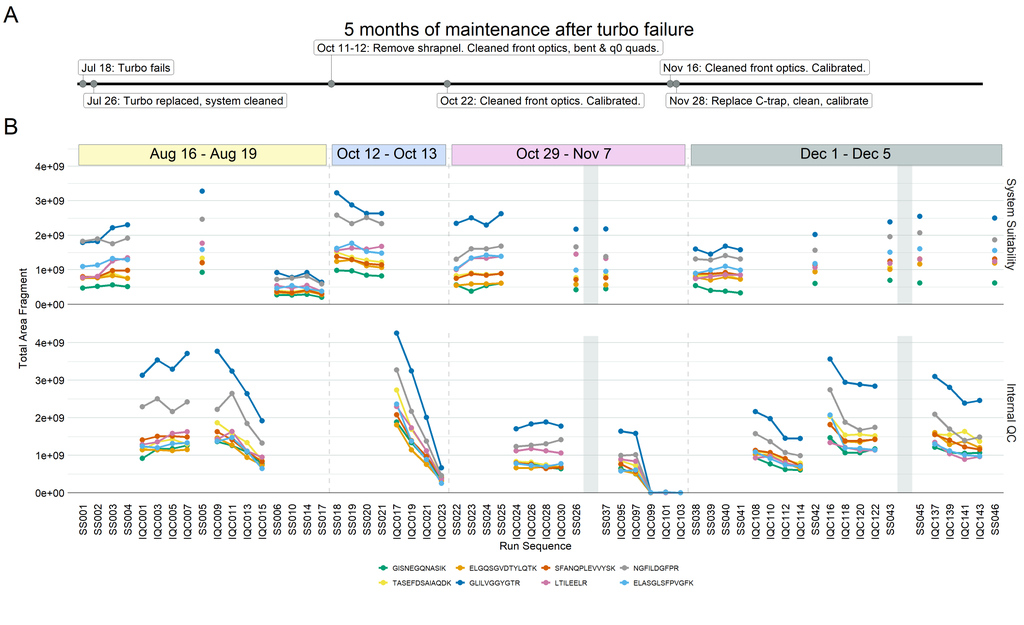

```r
# Print Figure 6
  fig6
```